# Enron Project Notebook

Loic Martins

2024-10-22

# Index

**1 - Preparation**  
1.1 - Packages and Libraries Installation  
1.2 - DataFrame creation  
1.3 - Specific function creation  
1.3.1 - Frequency Table creation  
1.3.2 - Email error checking  
1.3.3 - Status Analysis

**2 - Data Discovery**

**3 - Data Exploration and Cleaning**  
3.1 - Missing Values  
3.2 - Data type, outliers, data typos/misspelling  
3.2.1 - Employeelist DataFrame - Email Columns  
3.2.2 - Employeelist DataFrame - Status Column  
3.2.3 - Message DataFrame - Date  
3.2.4 - Recipient Info DataFrame - rvalue  
3.2.5 - Recipient Info DataFrame - rtype

**4 - Transformation**  
4.1 - Variable selection  
4.2 - Eron DataFrame creation  
4.2.1 - Transform the 3 DataFrames  
4.2.2 - Create the Enron DataFrame

**5 - Analysis**  
5.1 - Who is Enron’s most active employee?  
5.1.1 - Sender Enron’s Most Active Employees  
5.1.2 - Recipient Enron’s Most Active Employees  
5.1.3 - Enron’s most active employees overall  
5.2 - In which status are we most likely to be active, in terms of sending and receiving e-mail?  
5.2.1 - Visualize the activity for each status  
5.2.2 - Size of each status  
5.2.3 - Compare the size of the status and its activity  
5.2.4 - Check the distribution of each status  
5.2.5 - In which status are we most likely to be active, in terms of sending and receiving e-mail?  
5.3 - When was e-mail activity highest? And why?  
5.3.1 - Compare the global activity  
5.3.2 - Compare monthly activity between years  
5.4 - Analysis of the content of the messages  
5.4.1 - Text Processing  
5.4.2 - Most frequently used words  
5.4.3 - Number of words per year  
5.4.4 - Subjects Analysis

# Introduction

**Enron** was formed in 1985 and was one of the most famous energy and commodities US company. Enron had almost 20,000 employees and revenues of nearly $101 billion in 2000. But, Enron is also known as one of the largest corporate failures in U.S. history Indeed, in 2001, the company was at the center of an “accounting scandal” during which massive accounting fraud was revealed.

This is why an analysis of employee e-mails sent between 1999 and 2002 can be of interest.

To do this, we will go through various stages:  
1. **Preparation**: Project prerequisites.  
2. **Data Discovery**: Understand the data set.  
3. **Data Exploration and Cleaning**: Explore the different variables and clean the data.  
4. **Data Transformation**: Transform and prepare the data for analysis part.  
5. **Analysis** : Analyze data to answer various questions:  
- Analysis of employee e-mail activity: Who is Enron’s most active employee?  
- Analysis of the relationship between status and e-mail activity: In which status are we most likely to be active, in terms of sending and receiving e-mail?  
- Analysis of e-mail activity over time: When was e-mail activity highest? And why?  
- Analysis of the content of the messages: What were the Enron employees talking about?  
6. **Shiny application creation**: Allow the user to interact with the data.

# 1 - Preparation

## 1.1 -Packages and Libraries Installation

Before we begin, we can install the packages and libraries we will be using:

```r
library(rlist)
library(stringr)
library(tidyverse)
library(dplyr)
library(ggplot2)
library(lubridate)
library(textclean)
library(bubbles)
library(hrbrthemes)
library(gridExtra)
library(reshape2)
library(scales)
library(gghighlight)
library(wordcloud)
library(tm)
library(tidytext)
library(plyr)
```

## 1.2 - DataFrame creation

Load data and create 3 specifics DataFrame for each table:

```r
load('Enron.Rdata')

employee_df <- employeelist
message_df <- message
recipient_df <- recipientinfo
```

## 1.3 - Specific function creation

We’ll be using different custom functions at different stages of our work, so we’ve created different functions with different purposes:

### 1.3.1 - Frequency Table creation

```r
# We will use this function to create frequency table
# It takes as parameters:
# - column = table$column or variable (e.g. year) format
# - order = TRUE for decreasing order and FALSE for increasing order
# The function returns an ordered table of frequencies in Dataframe format

frequency_table <- function(column, order){

  frequency_table <- table(column)
  frequency_table <- as.data.frame(frequency_table)
  frequency_table <- frequency_table[order(frequency_table$Freq, decreasing = order),]
  frequency_table

}
```

### 1.3.2 - E-mail error checking

```r
# We will use this function for every column e-mail in the different table
# It takes as parameters:
# - table = the table name
# - column = the column name -> '...'
# Return a DataFrame with the rows where we have a problem with the spelling of the e-mail
# e.g. email_check(employee_df, 'Email_id')

email_check <- function(table, column){

  # We iterate through the Email_id column to create a list with all the FALSE values that represent an error in the spelling of the e-mail.
  regex_result <- list()
  pattern = '^(?!.*[-_.]{2})[\\w\\-_.&]*[\\@][\\w\\-]*[\\w+\\.]*[\\.][a-zA-Z]+'

  for (email in table[column]) {
    result <- str_detect(email, pattern)
    regex_result <- append(regex_result, result)
  }

  # We search all FALSE terms in the list and return the position that represent the row number in the data set
  row_list <- c(which(regex_result %in% c('FALSE')))

  # Using the position we print where we have an error in the spelling of the e-mail
  # And we filter by removing the empty cell because it was labeled as FALSE
  table_df <- table[row_list, ]
  table_df[table_df[column] != '', ]
  head(table_df, 10)
}
```

### 1.3.3 - Status Analysis

```r
# We will use this function to analyze the mean and median for each Enron employee status
# It takes as parameters:
# - DataFrame: the dataframe we need to calculate the mean and median
# - status : the name of the status
# This function return a DataFrame containing the status, the mean and the median

status_analysis <- function(dataframe, status){

  # Create an empty DataFrame
  status_analysis_df = data.frame()

  # Add the status
  status_analysis_df[1, 'Status'] <- status

  # Add the Median and the Mean
  status_analysis_df['Median'] <- ceiling(median(dataframe[dataframe$Status == status, 'Emails']))
  status_analysis_df['Mean'] <- ceiling(mean(dataframe[dataframe$Status == status, 'Emails']))
  status_analysis_df <- as.data.frame(status_analysis_df)

}
```

# 2 - Data Discovery

To start, we have 3 DataFrame:  
1. employeelist : the list of the employees with their personal information.  
2. message : the sender of the message and the message.  
3. recipientinfo : the recipient of the message.

The data was already pre-processed but we can explore it and see if we can make any change for the analysis part.

First, we can print all the variable names for each DataFrame to understand what kind of information we have:

```r
cat('The variables for the Employee List DataFrame are: ', colnames(employee_df), '.\n',
    'The variables for the Message DataFrame are: ', colnames(message_df), '.\n',
    'The variables for the Recipient DataFrame table are: ', colnames(recipient_df), '.')
```

```
## The variables for the Employee List DataFrame are:  eid firstName lastName Email_id Email2 Email3 EMail4 folder status .
##  The variables for the Message DataFrame are:  mid sender date message_id subject .
##  The variables for the Recipient DataFrame table are:  rid mid rtype rvalue .
```

It would then be interesting to know the size of the various DataFrames and compare them with the use of the ID for each DataFrame:  
- The MID for the Message table  
- The MID and RID for the Recipient Info tables  
- The e-mail ID for the Employee List table

```r
cat('The number of unique Email_id value for the Employee List DataFrame is',n_distinct(employee_df$Email_id),'.\n',
    'The number of rows for the Employee List DataFrame is',nrow(employee_df),'.\n',
    'The number of MID unique value for the Message DataFrame is',n_distinct(message_df$mid),'.\n',
    'The number of rows for the Message DataFrame is',nrow(message_df),'.\n',
    'The number of MID unique value for the Recipient Info DataFrame is',n_distinct(recipient_df$mid),'.\n',
    'The number of RID unique value for the Recipient Info DataFrame is',n_distinct(recipient_df$rid),'.\n',
    'The number of rows for the Recipient Info DataFrame is',nrow(message_df),'.\n')
```

```
## The number of unique Email_id value for the Employee List DataFrame is 149 .
##  The number of rows for the Employee List DataFrame is 149 .
##  The number of MID unique value for the Message DataFrame is 252759 .
##  The number of rows for the Message DataFrame is 252759 .
##  The number of MID unique value for the Recipient Info DataFrame is 252759 .
##  The number of RID unique value for the Recipient Info DataFrame is 2064442 .
##  The number of rows for the Recipient Info DataFrame is 252759 .
```

We now have a better understanding of how our dataset works, so we can explore it further.

# 3 - Data Exploration and Cleaning

## 3.1 - Missing Values

We can now check if we have missing values in our 3 DataFrames:

```r
cat('The number of missing values for the Employee List DataFrame is',sum(is.na(employee_df)),'.\n',
    'The number of missing values for the Message DataFrame is',sum(is.na(message_df)),'.\n',
    'The number of missing values for the Recipient Info DataFrame is',sum(is.na(recipient_df)),'.\n')
```

```
## The number of missing values for the Employee List DataFrame is 1 .
##  The number of missing values for the Message DataFrame is 0 .
##  The number of missing values for the Recipient Info DataFrame is 0 .
```

We have just one missing value in our Employee List DataFrame, so we can locate it:

```r
sapply(employee_df, function(x) sum(is.na(x)))
```

```
##       eid firstName  lastName  Email_id    Email2    Email3    EMail4    folder
##         0         0         0         0         0         0         0         0
##    status
##         1
```

The missing value is in the status column, so we can replace it by the default value “N/A” and check if the missing value is always present:

```r
employee_df$status[is.na(employee_df$status)] <- 'N/A'
cat("The number of missing values for the Employee List DataFrame is",sum(is.na(employee_df)))
```

```
## The number of missing values for the Employee List DataFrame is 0
```

## 3.2 - Data type, outliers, data typos/misspelling

Now we can check whether each column contains the correct data, with the right type/format, and contain no outliers:

1- Employee List DataFrame: - Check that the columns of our 4 “e-mails” are composed of an e-mail in the right format.  
We can check if all the values respect an e-mail pattern.  
- Look the data in the “status” column to identify the different status of employees.  
2- Message DataFrame:  
- Check the “date” column for format and date range.  
3- Recipient Info DataFrame:  
- For the column “rvalues”, we can check if all the values respect an e-mail pattern.  
- Look the data in the “rtype” column to identify the different e-mail etiquettes.

### 3.2.1 - Employeelist DataFrame - E-mail Columns

We can start with the Employee List DataFrame.

**a - Email_id**

First, we can call the function email_check to check the Email_ID column.

```r
email_check(employee_df, 'Email_id')
```

|  | eid | firstName | lastName | Email_id | Email2 | Email3 | EMail4 | folder | status |
| --- | --- | --- | --- | --- | --- | --- | --- | --- | --- |
| 24 | 24 | John | Forney | m..forney@enron.com | john.forney@enron.com |  |  | forney-j | Manager |
| 47 | 106 | Andrew | Lewis | h..lewis@enron.com | andrew.lewis@enron.com | andrew.h.lewis@enron.com |  | lewis-a | Director |
| 67 | 112 | Darron | Giron | c..giron@enron.com | darron.giron@enron.com | darron.c.giron@enron.com |  | giron-d | Employee |
| 88 | 65 | Mark | Haedicke | e..haedicke@enron.com | mark.haedicke@enron.com | mark.e.haedicke@enron.com |  | haedicke-m | Managing Director |
| 107 | 55 | Paul | Barbo | paul.y barbo@enron.com | barbo@enron.com | pybarbo@enron.com |  | ybarbo-p | Trader |
| 113 | 41 | Randall | Gay | l..gay@enron.com | randall.gay@enron.com | randall.l.gay@enron.com |  | gay-r | Employee |

We can see that we have a repeating pattern with 2 dots, and for a line we have a space.

```r
# We remove all spaces inside words
gsub(" ", "", employee_df$Email_id, , fixed=TRUE)
```

```
##   [1] "marie.heard@enron.com"         "mark.e.taylor@enron.com"
##   [3] "lindy.donoho@enron.com"        "lisa.gang@enron.com"
##   [5] "jeff.skilling@enron.com"       "lynn.blair@enron.com"
##   [7] "kim.ward@enron.com"            "kate.symes@enron.com"
##   [9] "kay.mann@enron.com"            "keith.holst@enron.com"
##  [11] "kenneth.lay@enron.com"         "kevin.hyatt@enron.com"
##  [13] "joe.quenet@enron.com"          "louise.kitchen@enron.com"
##  [15] "kevin.m.presto@enron.com"      "liz.taylor@enron.com"
##  [17] "kimberly.watson@enron.com"     "larry.f.campbell@enron.com"
##  [19] "larry.may@enron.com"           "joe.stepenovitch@enron.com"
##  [21] "kevin.ruscitti@enron.com"      "kam.keiser@enron.com"
##  [23] "joe.parks@enron.com"           "m..forney@enron.com"
##  [25] "john.arnold@enron.com"         "lavorato@enron.com"
##  [27] "john.zufferli@enron.com"       "john.hodge@enron.com"
##  [29] "john.griffith@enron.com"       "jonathan.mckay@enron.com"
```

[output cut: 60 more lines]

```r
# We can replace all the double dots by a dot
employee_df$Email_id <- gsub('..', '.', employee_df$Email_id, fixed=TRUE)

head(employee_df, 5)
```

|  | eid | firstName | lastName | Email_id | Email2 | Email3 | EMail4 | folder | status |
| --- | --- | --- | --- | --- | --- | --- | --- | --- | --- |
| 1 | 13 | Marie | Heard | marie.heard@enron.com |  |  |  | heard-m | N/A |
| 2 | 6 | Mark | Taylor | mark.e.taylor@enron.com | mark.taylor@enron.com | e.taylor@enron.com |  | taylor-m | Employee |
| 3 | 19 | Lindy | Donoho | lindy.donoho@enron.com | ldonoho@enron.com |  |  | donoho-l | Employee |
| 4 | 115 | Lisa | Gang | lisa.gang@enron.com |  |  |  | gang-l | N/A |
| 5 | 129 | Jeffrey | Skilling | jeff.skilling@enron.com | jeffrey.skilling@enron.com |  |  | skilling-j | CEO |

**b - Email2**

Now we can call our “email_check” function for the Email2:

```r
email_check(employee_df, 'Email2')
```

|  | eid | firstName | lastName | Email_id | Email2 | Email3 | EMail4 | folder | status |
| --- | --- | --- | --- | --- | --- | --- | --- | --- | --- |
| 1 | 13 | Marie | Heard | marie.heard@enron.com |  |  |  | heard-m | N/A |
| 4 | 115 | Lisa | Gang | lisa.gang@enron.com |  |  |  | gang-l | N/A |
| 9 | 52 | Kay | Mann | kay.mann@enron.com |  |  |  | mann-k | Employee |
| 15 | 92 | Kevin | Presto | kevin.m.presto@enron.com | m..presto@enron.com | kevin.presto@enron.com |  | presto-k | Vice President |
| 17 | 20 | Kimberly | Watson | kimberly.watson@enron.com |  |  |  | watson-k | N/A |
| 19 | 102 | Larry | May | larry.may@enron.com |  |  |  | may-l | Director |
| 21 | 60 | Kevin | Ruscitti | kevin.ruscitti@enron.com |  |  |  | ruscitti-k | Trader |
| 23 | 95 | Joe | Parks | joe.parks@enron.com |  |  |  | parks-j | N/A |
| 25 | 44 | John | Arnold | john.arnold@enron.com |  |  |  | arnold-j | Manager |
| 27 | 77 | John | Zufferli | john.zufferli@enron.com |  |  |  | zufferli-j | Vice President |

We have:  
1- For the majority of the e-mails, we have the same pattern with a double dots.  
2- Specific errors:  
- Space problem: scott . hendrikcson@enron.com  
- Double points and an @ are missing: d..baughman.com  
- Using of “?”: matthew.smith?@enron.com

```r
# We can specically replace our 3 e-mails with a specific pattern
conditions <- c('d..baughman.com', 'matthew.smith?@enron.com', 'scott . hendrikcson@enron.com')
replace_values <- c('d.baughman@enron.com', 'matthew.smith@enron.com', 'scott.hendrikcson@enron.com')

employee_df$Email2 <- replace(employee_df$Email2, employee_df$Email2 %in% conditions, replace_values)

# We can replace the double dots with a dot
employee_df$Email2 <- gsub('..', '.', employee_df$Email2, fixed=TRUE)
```

**c - Email3**

For the Email3 column:

```r
email_check(employee_df, 'Email3')
```

|  | eid | firstName | lastName | Email_id | Email2 | Email3 | EMail4 | folder | status |
| --- | --- | --- | --- | --- | --- | --- | --- | --- | --- |
| 1 | 13 | Marie | Heard | marie.heard@enron.com |  |  |  | heard-m | N/A |
| 3 | 19 | Lindy | Donoho | lindy.donoho@enron.com | ldonoho@enron.com |  |  | donoho-l | Employee |
| 4 | 115 | Lisa | Gang | lisa.gang@enron.com |  |  |  | gang-l | N/A |
| 5 | 129 | Jeffrey | Skilling | jeff.skilling@enron.com | jeffrey.skilling@enron.com |  |  | skilling-j | CEO |
| 6 | 18 | Lynn | Blair | lynn.blair@enron.com | lynnblair@enron.com |  |  | blair-l | Director |
| 7 | 33 | Kim | Ward | kim.ward@enron.com | kward@enron.com |  |  | ward-k | N/A |
| 8 | 149 | Kate | Symes | kate.symes@enron.com | ksymes@enron.com |  |  | symes-k | Employee |
| 9 | 52 | Kay | Mann | kay.mann@enron.com |  |  |  | mann-k | Employee |
| 10 | 21 | Keith | Holst | keith.holst@enron.com | kholst@enron.com |  |  | holst-k | Director |
| 11 | 127 | Kenneth | Lay | kenneth.lay@enron.com | kenneth_lay@enron.com |  |  | lay-k | CEO |

We have the same pattern with a double dots:

```r
# We can replace the double dots with a dot
employee_df$Email3 <- gsub('..', '.', employee_df$Email3, fixed=TRUE)
```

**d - Email4**

For the Email4 column:

```r
email_check(employee_df, 'EMail4')
```

|  | eid | firstName | lastName | Email_id | Email2 | Email3 | EMail4 | folder | status |
| --- | --- | --- | --- | --- | --- | --- | --- | --- | --- |
| 1 | 13 | Marie | Heard | marie.heard@enron.com |  |  |  | heard-m | N/A |
| 2 | 6 | Mark | Taylor | mark.e.taylor@enron.com | mark.taylor@enron.com | e.taylor@enron.com |  | taylor-m | Employee |
| 3 | 19 | Lindy | Donoho | lindy.donoho@enron.com | ldonoho@enron.com |  |  | donoho-l | Employee |
| 4 | 115 | Lisa | Gang | lisa.gang@enron.com |  |  |  | gang-l | N/A |
| 5 | 129 | Jeffrey | Skilling | jeff.skilling@enron.com | jeffrey.skilling@enron.com |  |  | skilling-j | CEO |
| 6 | 18 | Lynn | Blair | lynn.blair@enron.com | lynnblair@enron.com |  |  | blair-l | Director |
| 7 | 33 | Kim | Ward | kim.ward@enron.com | kward@enron.com |  |  | ward-k | N/A |
| 8 | 149 | Kate | Symes | kate.symes@enron.com | ksymes@enron.com |  |  | symes-k | Employee |
| 9 | 52 | Kay | Mann | kay.mann@enron.com |  |  |  | mann-k | Employee |
| 10 | 21 | Keith | Holst | keith.holst@enron.com | kholst@enron.com |  |  | holst-k | Director |

We have the same pattern with a double dots:

```r
# Replace the double dots with a dot
employee_df$EMail4 <- gsub('..', '.', employee_df$EMail4, fixed=TRUE)
```

### 3.2.2 - Employeelist DataFrame - Status Column

We can now check the “status” column using our frequency table function:

```r
frequency_table_status <- frequency_table(employee_df$status, 'TRUE')
frequency_table_status
```

|  | column | Freq |
| --- | --- | --- |
| 3 | Employee | 41 |
| 7 | N/A | 32 |
| 10 | Vice President | 23 |
| 2 | Director | 14 |
| 5 | Manager | 14 |
| 9 | Trader | 13 |
| 1 | CEO | 4 |
| 8 | President | 4 |
| 6 | Managing Director | 3 |
| 4 | In House Lawyer | 1 |

We can see that there are no errors in the various statuses, but we can quickly visualize the data:

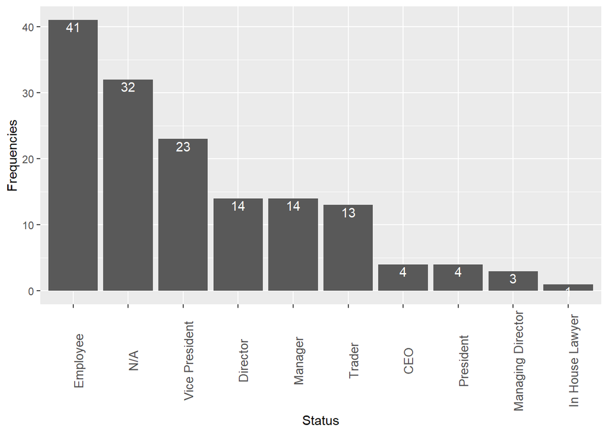

```r
ggplot(frequency_table_status, aes(x=reorder(column, -Freq), Freq)) +
  geom_bar(stat = "identity") +
  theme(axis.text.x = element_text(angle = 90, size = 10)) +
  labs(x = 'Status', y = 'Frequencies') +
  geom_text(
    aes(label = Freq),
    vjust = 1.2,
    hjust = 0.5,
    color = 'white')
```

We can see that the most represented status is that of Employee, but we also have a significant number of people with no status mentioned.

### 3.2.3 - Message DataFrame - Date

We start by checking whether the column is in Date format:

```r
is_date <- is.Date(message_df$date)
is_date
```

```
## [1] TRUE
```

We can now check the date range in our DataFrame to identify any outliers or misspellings. To do so, we can use our frequency table function:

```r
# Extract the year of the date
year <- format(message_df$date, "%Y")

# Call the Frequency Table function
frequency_table(year, 'TRUE')
```

|  | column | Freq |
| --- | --- | --- |
| 8 | 2001 | 156320 |
| 7 | 2000 | 68707 |
| 9 | 2002 | 22562 |
| 6 | 1999 | 4760 |
| 1 | 0001 | 205 |
| 5 | 1998 | 85 |
| 2 | 0002 | 53 |
| 10 | 2004 | 53 |
| 3 | 1979 | 6 |
| 14 | 2044 | 3 |

[output cut: 4 more lines]

It seems interesting because we have:  
- Outliers: 2044 and 2043. It’s just not possible. Perhaps 1979 is also out of our scope.  
- Spelling/typographical errors: we have 0001 and 0002. They often represent 2001 and 2002.

So, we can now:  
- We can transform 0001 into 2021 and 0002 into 2002.  
- Remove the date with the date: 2044, 2043 and 1979.

```r
# Create 3 columns for the year, the month and the day
message_df <- message_df %>%
                mutate(Year = year(message_df$date)) %>%
                mutate(Month = month(message_df$date)) %>%
                mutate(Day = day(message_df$date))

# Transform 1 into 2021 and 2 into 2002
message_df$Year[message_df$Year == 1] <- 2001
message_df$Year[message_df$Year == 2] <- 2002

# Remove the first date column
message_df$date <- NULL

# Create a new date column and convert it in a date format
message_df$date <- paste(message_df$Year, message_df$Month, message_df$Day, sep = "-")
message_df$date <- as.Date(message_df$date , format = "%Y-%m-%d")

#Remove the row where the date is 1979, 2043 and 2044
message_df <- message_df[!(message_df$date > "2021-01-01" | message_df$date < "1980-01-01"), ]
```

### 3.2.4 - Recipient Info DataFrame - rvalue

Rvalue is a column composed of e-mails. We can use the email_check function to check the spelling of e-mails:

```r
email_check(recipient_df, 'rvalue')
```

|  | rid | mid | rtype | rvalue |
| --- | --- | --- | --- | --- |
| 15 | 81 | 60 | TO | murray.o neil@enron.com |
| 81 | 147 | 66 | TO | m..forney@enron.com |
| 89 | 155 | 66 | TO | murray.o neil@enron.com |
| 437 | 503 | 112 | TO | Undisclosed-Recipient |
| 460 | 526 | 115 | TO | Undisclosed-Recipient |
| 558 | 624 | 119 | TO | m..forney@enron.com |
| 624 | 690 | 120 | TO | m..forney@enron.com |
| 650 | 716 | 121 | TO | Undisclosed-Recipient |
| 674 | 740 | 128 | TO | Undisclosed-Recipient |
| 675 | 741 | 129 | TO | Undisclosed-Recipient |

It’s interesting because we find the same than the precedent tables:  
- Double dots.  
- Space in middle of e-mail.

But we have also:  
- “Undisclosed-Recipient” which represent a hidden e-mail recipient.  
- New patterns: e.g.mark_a._hoppe@calpx.com.  
- Name of maybe a mailing list: e.g. Enron Transportation Services Everyone - All@ENRON

First, we will remove the double dots and the spaces:

```r
# Remove all spaces inside words
recipient_df$rvalue <- gsub(" ", "", recipient_df$rvalue, , fixed=TRUE)

# Replace all the double dots by a dot
recipient_df$rvalue <- gsub('..', '.', recipient_df$rvalue, fixed=TRUE)
```

We can now take a closer look at the remaining data using our frequency table function:

```r
rvalue_false <- email_check(recipient_df, 'rvalue')
frequency_table(rvalue_false$rvalue, 'TRUE')
```

|  | column | Freq |
| --- | --- | --- |
| 2 | Undisclosed-Recipient | 8 |
| 1 | mark_a._hoppe@calpx.com | 2 |

Just to uniform the spelling of theses e-mails we will replace all “*.” and ”-.” by ”*” or “-”.

```r
recipient_df$rvalue <- mgsub(recipient_df$rvalue, c('_.', '._', '-.', '.-'), c('_', '_', '.', '-'),
                                fixed=TRUE)
```

To finish, we can just take a look on our frequencie table for our rvalue column:

```r
frequency_table(recipient_df$rvalue, 'TRUE')
```

|  | column | Freq |
| --- | --- | --- |
| 47261 | no.address@enron.com | 19198 |
| 28291 | jeff.dasovich@enron.com | 11137 |
| 52852 | richard.shapiro@enron.com | 11015 |
| 60158 | steven.j.kean@enron.com | 10873 |
| 26798 | james.d.steffes@enron.com | 10615 |
| 61355 | tana.jones@enron.com | 9781 |
| 56028 | sara.shackleton@enron.com | 9633 |
| 40942 | mark.e.taylor@enron.com | 9090 |
| 39383 | louise.kitchen@enron.com | 7604 |
| 49352 | pete.davis@enron.com | 7509 |

[output cut: 9990 more lines]

When we take a look at our frequency table, we can se that:  
- The most frequent address is unkwown: “no.address@enron.com”  
- We have different type of recipients:  
- Enron employees: @enron.com.  
- Mailing List: AllEnronWorldwide@ENRON.  
- External contacts: gfergus@brobeck.com.  
- The majority of e-mail recipients are Enron employees.

### 3.2.5 - Recipient Info DataFrame - rtype

To finish the Exploration and Cleaning part, we can take a look at our rtype variable that represent the different e-mail etiquette.We’ll call the frequency table function:

```r
frequency_table_rtype <- frequency_table(recipient_df$rtype, 'TRUE')
frequency_table_rtype
```

|  | column | Freq |
| --- | --- | --- |
| 3 | TO | 1556994 |
| 2 | CC | 253735 |
| 1 | BCC | 253713 |

We can validate this column because we have 3 right values:  
- TO: the main recipient(s) of the e-mail.  
- CC: Carbon Copy.Send additional copies of a single e-mail to one or more recipients.  
- BCC: Blind Carbon Copy. Sends copies of the e-mail to multiple recipients but none of the recipients are made aware of who else has received the e-mail.

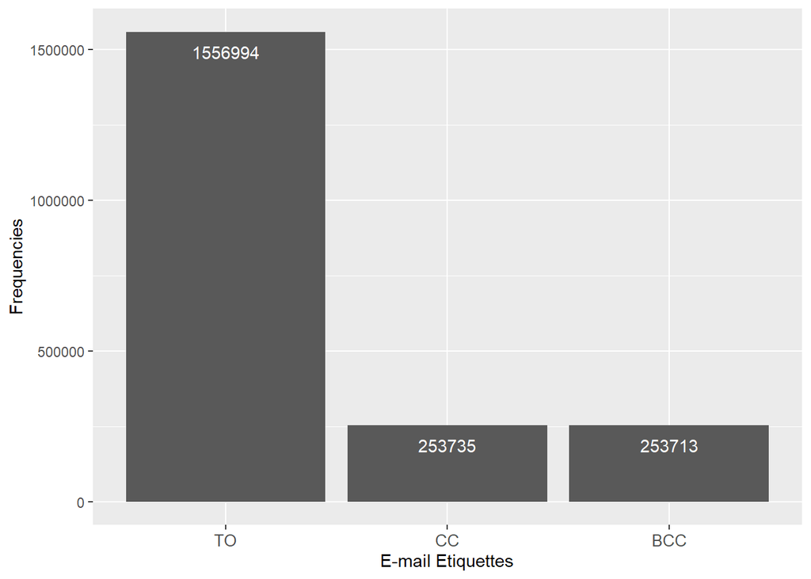

```r
ggplot(frequency_table_rtype, aes(x=reorder(column, -Freq), Freq)) +
  geom_bar(stat = "identity") +
  theme(axis.text.x = element_text(angle = 0, size = 10)) +
  labs(x = 'E-mail Etiquettes', y = 'Frequencies') +
  geom_text(
    aes(label = Freq),
    vjust = 2,
    hjust = 0.5,
    color = 'white')
```

We can see that the TO label is used more often, but this seems normal as it’s the main label used when sending e-mail.

# 4 - Transformation

Related to our analysis goals, we will transform our DataFrames to create one table and facilitate the analysis process.

## 4.1 - Variable selection

We don’t need to keep all the variables.  
So, for our new DataFrame we can:  
- Use the Message DataFrame as a “main” DataFrame  
- For every message (unique MID), we can join:  
- Name, Last Name, status and EID of the sender.  
- rvalue, rtype and rid of the recipient.

The goal is to have one row for one message (unique MID) that contains all the information needed.

## 4.2 - Eron DataFrame creation

### 4.2.1 - Transform the 3 DataFrames

We will create 3 new DataFrames selecting our main variables.

```r
list_variable_message <- c('mid', 'sender', 'subject', 'Year', 'Month', 'Day', 'date')
list_variable_employee <- c('eid', 'firstName', 'lastName', 'Email_id', 'Email2', 'Email3', 'EMail4', 'status')

message_df_2 <- message_df[ , list_variable_message]
employee_df_2 <- employee_df[ , list_variable_employee]
recipient_df_2 <- recipient_df
```

Now, we’ll modify the name of the different columns.

```r
# Message DataFrame
message_df_2 <- message_df_2 %>%
  dplyr::rename('MessageID' = 'mid',
         'SenderEmail' = 'sender',
         'Subject' = 'subject',
         'DateYear' = 'Year',
         'DateMonth'= 'Month',
         'DateDay'= 'Day',
         'Date' = 'date')

# Recipient DataFrame
recipient_df_2 <- recipient_df_2 %>%
  dplyr::rename('MessageID' = 'mid',
               'RecipientID' = 'rid',
               'RecipientType' = 'rtype',
               'RecipientEmail' = 'rvalue')


# Employee DataFrame
# We'll create a column EmployeeName
employee_df_2$EmployeeName <- paste(employee_df_2$firstName, employee_df_2$lastName, sep = " ")

# Rename the columns and remove the first, last name and folder columns
employee_df_2 <- employee_df_2[,!names(employee_df_2) %in% c('firstName', 'lastName', 'folder')]

employee_df_2 <- employee_df_2 %>%
  dplyr::rename('EmployeeID' = 'eid',
               'Email1' = 'Email_id',
               'Email4' = 'EMail4',
               'Status' = 'status')
```

### 4.2.2 - Create the Enron DataFrame

The Enron DataFrame will contain:  
- MessageID  
- Date  
- DateYear  
- DateMonth  
- DateDay  
- Subject  
- RecipientType  
- RecipientID

- SenderEmail
- SenderName
- SenderStatus
- SenderEmployeeID
- RecipientEmail
- RecipientName
- RecipientStatus
- RecipientEmployeeID

To do that, we will need to join:  
- Message Table with Employee DataFrame  
- The result of the join with Recipient DataFrame  
- The result of the join with Employee DataFrame

**a - Join the Message DataFrame and the Employee DataFrame**

```r
# Join for the Email1
df_join_1 <- inner_join(message_df_2, employee_df_2, by = c('SenderEmail' = 'Email1'))

# Retrieve all message ID that correspond to an employee's e-mail address
list_message_id_1 <- df_join_1[, 'MessageID']

# Create a new DataFrame with the remaining rows
remaining_rows <- message_df_2[!message_df_2$MessageID %in% list_message_id_1, ]

# Join a new times the new DataFrame with the Email2 of the Employee DataFrame
df_join_2 <- inner_join(remaining_rows, employee_df_2, by = c('SenderEmail' = 'Email2'))


# Repeat the process for the Email3 of the Employee DataFrame
list_recipient_id <- df_join_2[, 'MessageID']
list_message_id_2 <- c(list_message_id_1, list_recipient_id)
remaining_rows <- message_df_2[!message_df_2$MessageID %in% list_message_id_2, ]
df_join_3 <- inner_join(remaining_rows, employee_df_2, by = c('SenderEmail' = 'Email3'))

# Repeat the process for the Email4 of the Employee DataFrame
list_recipient_id <- df_join_3[, 'MessageID']
list_message_id_3 <- c(list_message_id_2, list_recipient_id)
remaining_rows <- message_df_2[!message_df_2$MessageID %in% list_message_id_3, ]
df_join_4 <- inner_join(remaining_rows, employee_df_2, by = c('SenderEmail' = 'Email4'))

# Repeat the same process to retrieve the remaining rows that are not joined during the process
list_recipient_id <- df_join_4[, 'MessageID']
list_message_id_4 <- c(list_message_id_3, list_recipient_id)
remaining_df <- message_df_2[!message_df_2$MessageID %in% list_message_id_4, ]
```

We now have 5 DataFrames with different rows. We can group them together and check whether we have the same number of rows, and therefore message IDs as at the start.

```r
enron_df <- df_join_1 %>%
  bind_rows(df_join_2) %>%
  bind_rows(df_join_3) %>%
  bind_rows(df_join_4) %>%
  bind_rows(remaining_df)

rows_id_start = n_distinct(message_df$mid)
rows_id_end = n_distinct(enron_df$MessageID)
result_row_number = rows_id_start == rows_id_end

cat('At the beginning, we had', rows_id_start, 'message ID (unique row)', '.\n',
      'Now, we have,', rows_id_end,'message ID (unique row)', '.\n',
      'Is the number of message ID (unique row) the same ? ->', result_row_number, '.')
```

```
## At the beginning, we had 252749 message ID (unique row) .
##  Now, we have, 252749 message ID (unique row) .
##  Is the number of message ID (unique row) the same ? -> TRUE .
```

Now, we can remove the columns : Email1, Email2, Email3 and Email4:

```r
enron_df <- enron_df[,!names(enron_df) %in% c('Email1', 'Email2', 'Email3', 'Email4')]
```

Before to continue, we can check the number of missing values in the DataFrame. It corresponds to senders who do not appear in the employee table.

```r
colSums(is.na(enron_df))
```

```
##    MessageID  SenderEmail      Subject     DateYear    DateMonth      DateDay
##            0            0            0            0            0            0
##         Date   EmployeeID       Status EmployeeName
##            0       148656       148656       148656
```

We can replace all of these values by “N/A”.

```r
enron_df <- enron_df %>% replace(is.na(.), 'N/A')
```

We now have a DataFrame containing information about the message and the associated sender, in the case of an employee.

Before continuing, we will rename the column for greater clarity in our DataFrame :

```r
enron_df <- enron_df %>%
  dplyr::rename('SenderEmployeeID' = 'EmployeeID',
               'SenderStatus' = 'Status',
               'SenderName' = 'EmployeeName')
```

**b - Join the Eron DataFrame and the Recipient Table**

Now, we want to join the information of the recipient with the appropriate e-mail. To do that, we will use a left join on the “MessageID”.

```r
enron_df <- enron_df %>% left_join(recipient_df_2,
            by='MessageID')
```

We now have a DataFrame with 2,064,418 lines. This is normal, because for the same message ID, there can be several recipients. But we can see that our Recipient DataFrame contains 2,064,442. So we’ve lost 24 lines. This is because the Recipient DataFrame contains messages (IDs) that don’t appear in our Message DataFrame.

We’re not going to recover these lines because we don’t have any information on the sender.

**c - Join the Eron DataFrame and the Employee DataFrame**

Finally, we need to join the Enron DataFrame to the Employee DataFrame again, in order to retrieve the employee information linked to the recipient, if we have it.

We’ll use the same code as for the previous join.

```r
number_recipientid_start = n_distinct(enron_df$RecipientID)
number_rows_start = nrow(enron_df)

# Join for the Email1
df_join_1 <- inner_join(enron_df, employee_df_2, by = c('RecipientEmail' = 'Email1'))

# Retrieve all recipient ID that are joined
list_recipient_id_1 <- df_join_1[, 'RecipientID']

# Create a new DataFrame with the remaining rows (not joined)
remaining_rows <- enron_df[!enron_df$RecipientID %in% list_recipient_id_1, ]

# Join a new times the remaining DataFrame with the Email2 of the Employee DataFrame
df_join_2 <- inner_join(remaining_rows, employee_df_2, by = c('RecipientEmail' = 'Email2'))

# Repeat the process for the Email3 of the Employee DataFrame
list_recipient_id <- df_join_2[, 'RecipientID']
list_recipient_id_2 <- c(list_recipient_id_1, list_recipient_id)
remaining_rows <- enron_df[!enron_df$RecipientID %in% list_recipient_id_2, ]
df_join_3 <- inner_join(remaining_rows, employee_df_2, by = c('RecipientEmail' = 'Email3'))

# Repeat the process for the Email4 of the Employee DataFrame
list_recipient_id <- df_join_3[, 'RecipientID']
list_recipient_id_3 <- c(list_recipient_id_2, list_recipient_id)
remaining_rows <- enron_df[!enron_df$RecipientID %in% list_recipient_id_3, ]
df_join_4 <- inner_join(remaining_rows, employee_df_2, by = c('RecipientEmail' = 'Email4'))

# Repeat the same process to retrieve the remaining rows that are not joined during the process
list_recipient_id <- df_join_4[, 'RecipientID']
list_message_id_4 <- c(list_recipient_id_3, list_recipient_id)
remaining_df <- enron_df[!enron_df$RecipientID %in% list_message_id_4, ]

# We now have 5 DataFrames with different rows
# Group them together
enron_df <- bind_rows(df_join_1, df_join_2, df_join_3, df_join_4, remaining_df)

# Count the number of Rows and RecipientID distinct value and compare it with the old number
number_recipientid_end = n_distinct(enron_df$RecipientID)
number_rows_end = nrow(enron_df)
result_recipientid_number = number_recipientid_start == number_recipientid_end
result_rows_number = number_rows_start == number_rows_end

cat('Before making the junction, we had', number_recipientid_start,'recipient ID and,', number_rows_start,'rows', '.\n',
      'After the join, we have,', number_recipientid_end,'recipient ID and,', number_rows_end,'rows', '.\n',
      'Is the number of Recipient ID the same before and after? ->', result_recipientid_number, '.\n',
      'Is the number of Rows the same before and after? ->', result_recipientid_number, '.')
```

```
## Before making the junction, we had 2064418 recipient ID and, 2064418 rows .
##  After the join, we have, 2064418 recipient ID and, 2064418 rows .
##  Is the number of Recipient ID the same before and after? -> TRUE .
##  Is the number of Rows the same before and after? -> TRUE .
```

We have the same unique recipient ID number after and before, and we have the same number of rows and Recipient ID, so we haven’t lost any lines and we don’t have any duplicates.

Now, we can clean our Enron DataFrame.

```r
# Remove the e-mails columns
enron_df <- enron_df[,!names(enron_df) %in% c('Email1', 'Email2', 'Email3', 'Email4')]

# Rename some specific columns for recipient employee information
enron_df <- enron_df %>%
  dplyr::rename('RecipientName' = 'EmployeeName',
               'RecipientStatus' = 'Status',
               'RecipientEmployeeID' = 'EmployeeID')

# We have missing values in the columns Employee ID, Status and EmployeeName
# It corresponds to recipient who do not appear in the eEame We can replace all of these values by "N/A"

enron_df <- enron_df %>% replace(is.na(.), 'N/A')
```

```r
# Check if we have missing values
sapply(enron_df, function(x) sum(is.na(x)))
```

```
##           MessageID         SenderEmail             Subject            DateYear
##                   0                   0                   0                   0
##           DateMonth             DateDay                Date    SenderEmployeeID
##                   0                   0                   0                   0
##        SenderStatus          SenderName         RecipientID       RecipientType
##                   0                   0                   0                   0
##      RecipientEmail RecipientEmployeeID     RecipientStatus       RecipientName
##                   0                   0                   0                   0
```

To finish we can reorder the columns.

```r
col_order <- c('MessageID', 'Date', 'DateYear', 'DateMonth', 'DateDay', 'Subject',
               'SenderEmail', 'SenderName', 'SenderStatus', 'SenderEmployeeID',
               'RecipientID', 'RecipientType', 'RecipientEmail', 'RecipientName',
               'RecipientStatus', 'RecipientEmployeeID')

enron_df <- enron_df[, col_order]
```

Now we have a clean DataFrame that groups our 3 tables:  
- Message information.  
- Sender information and if it’s an employee, we have this personal information.  
- Recipient information and if it’s an employee, we have this personal information.

We can now go to the analysis step with a unique Dataframe.

# 5 - Analysis

As a reminder here is our analysis goals:  
1. Analysis of employee e-mail activity: Who is Enron’s most active employee?  
2. Analysis of the relationship between status and e-mail activity: In which status are we most likely to be active, in terms of sending and receiving e-mail?  
3. Analysis of e-mail activity over time: When was e-mail activity highest? And why?  
4. Analysis of the content of the messages: What were the Enron employees talking about?

## 5.1 - Who is Enron’s most active employee?

We can divide this part in 3 steps:  
- Sender Enron’s Most Active Employees.  
- Recipient Enron’s Most Active Employees.  
- Enron’s most active employees overall.

For every step we can:  
1- Create a specific DataFrame.  
2- Analyze the distribution.  
3- Display the most active Enron employees.

Before we begin, it is important to define who an Enron employee is.  
According to our DataFrames, an Enron employee is a person who is listed in our Employee DataFrame. So, in our main DataFrame, they are identified because they have an EmployeeID.

### 5.1.1 - Sender Enron’s Most Active Employees

**a - Create a DataFrame**

In this section, we focus on Enron employees who are the “sender”.  
So we can create a specific DataFrame in which we can remove all messages in which we have no Employee ID about the sender. This means that the sender was not in our Employee DataFrame.

```r
enron_df_sender <- enron_df[enron_df$SenderEmployeeID != 'N/A', ]
```

In fact, we have several lines for a single message ID because we have one message ID for several recipient IDs. A message ID refers to several recipients, but it refers to a single sender. So we’ll keep one line for one message ID.

```r
enron_df_sender <- enron_df_sender %>% distinct(MessageID, .keep_all = TRUE)
```

Finally, we can create a frequency table to know the number of e-mails sent by employees.

```r
frequency_table_sender = frequency_table(enron_df_sender$SenderName, 'TRUE')
frequency_table_sender <- frequency_table_sender %>%
  dplyr::rename('EmployeeName' = 'column',
                'EmailSent' = 'Freq')
frequency_table_sender
```

|  | EmployeeName | EmailSent |
| --- | --- | --- |
| 51 | Jeff Dasovich | 6273 |
| 145 | Vince Kaminski | 5838 |
| 69 | Kay Mann | 5100 |
| 122 | Sara Shackleton | 4797 |
| 138 | Tana Jones | 4437 |
| 14 | Chris Germany | 3686 |
| 94 | Matthew Lenhart | 2784 |
| 25 | Debra Perlingiere | 2549 |
| 132 | Steven Kean | 2277 |
| 40 | Gerald Nemec | 2275 |

[output cut: 136 more lines]

We can see that we have 146 employees represented:

```r
nrow(frequency_table_sender)
```

```
## [1] 146
```

**b - Analyze the Distribution**

```r
# Use a simple function to get an overview of our Frequency variable

summary <- summary(frequency_table_sender$EmailSent)
summary
```

```
##    Min. 1st Qu.  Median    Mean 3rd Qu.    Max.
##     1.0   101.0   301.5   713.0   840.5  6273.0
```

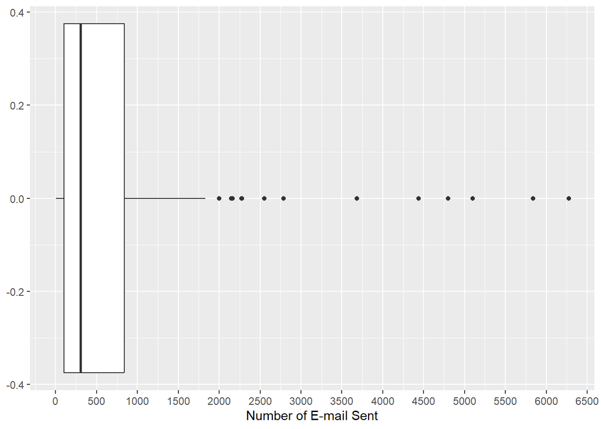

```r
# Create a Boxplot
breaks <- seq(0, 6500, by = 500)

ggplot(frequency_table_sender, aes(x = EmailSent)) +
  geom_boxplot() +
  scale_x_continuous(breaks = breaks) +
  xlab('Number of E-mail Sent')
```

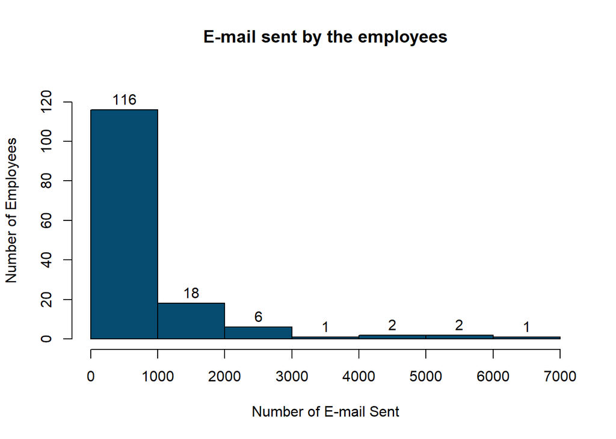

```r
# Visualize the data using an histogram
h <- hist(frequency_table_sender$EmailSent,
          breaks = 6,
          ylim = c(0, 130),
          col = '#054C70',
          border= 'black',
          main = 'E-mail sent by the employees',
          xlab='Number of E-mail Sent',
          ylab = 'Number of Employees')
text(h$mids,h$counts,labels=h$counts, adj=c(0.5, -0.5))
```

Concerning the distribution, we can see that:  
- We have an important range of values: 1 to 6273. This means that we have one employee who has sent 1 e-mail and another who has sent over 6,000 e-mails.  
- The majority of the employees send between 101 and 840 e-mails.With a median of 301 e-mails.  
- We have around 12 employees who are not part of this majority because they sent a signficant number of e-mails: more than 2,000.  
- We have a Right Skewed distribution. It’s logical because the majority of the employees sent between 100 and 840 e-mails.

**c - Sender Enron’s Most Active Employees**

```r
top_variable <- 10
rest <- top_variable - 3

top_employees_sender <- frequency_table_sender %>% top_n(top_variable)
```

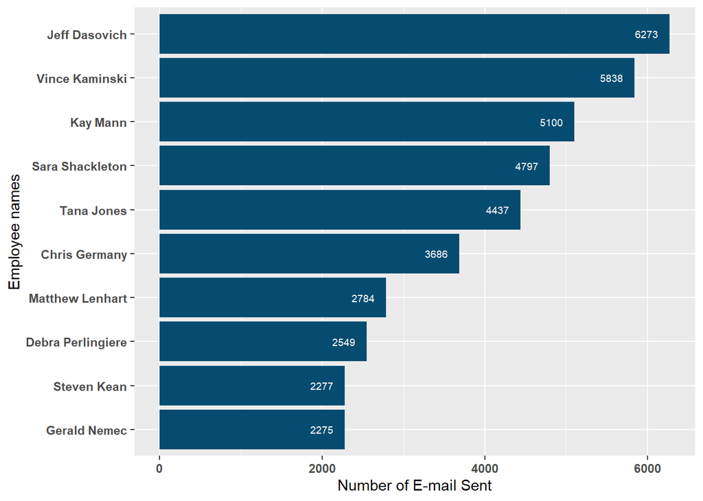

```r
ggplot(top_employees_sender, aes(x=reorder(EmployeeName, EmailSent), EmailSent)) +
  geom_bar(stat = 'identity', fill = '#054C70') +
  coord_flip() +
  labs(x = 'Employee names', y = 'Number of E-mail Sent') +
  geom_text(
  aes(label = EmailSent),
  size = 2.5,
  vjust = 0.5,
  hjust = 1.5,
  color = 'white') +
  theme(axis.text = element_text(face="bold"))
```

We now have an overview of the 10 employees who send the most e-mails and we can see that between the first and the tenth employee we have a difference of 4,000 e-mails.

### 5.1.2 - Recipient Enron’s Most Active Employees

We can apply the same process to the recipient: Which employee receives the most e-mails?

**a - Create a DataFrame**

In this section, we focus on Enron employees who are the “recipient”. So we can create a specific DataFrame in which we can remove all messages in which we have no Employee ID about the recipient. This means that the recipient was not in our Employee DataFrame. And in this case, we keep all rows because we want to have unique Recipient ID.

```r
enron_df_recipient <- enron_df[enron_df$RecipientEmployeeID != 'N/A', ]
```

Finally, we can create a frequency table to know the number of e-mails receive by employees.

```r
frequency_table_recipient = frequency_table(enron_df_recipient$RecipientName, 'TRUE')
frequency_table_recipient <- frequency_table_recipient %>%
  dplyr::rename('EmployeeName' = 'column',
                'EmailReceive' = 'Freq')
frequency_table_recipient
```

|  | EmployeeName | EmailReceive |
| --- | --- | --- |
| 51 | Jeff Dasovich | 11137 |
| 115 | Richard Shapiro | 11015 |
| 134 | Steven Kean | 10876 |
| 46 | James Steffes | 10620 |
| 140 | Tana Jones | 9781 |
| 124 | Sara Shackleton | 9633 |
| 89 | Mark Taylor | 9091 |
| 83 | Louise Kitchen | 7604 |
| 147 | Vince Kaminski | 6576 |
| 86 | Mark Guzman | 5907 |

[output cut: 138 more lines]

We can see that we have 148 employees represented:

```r
nrow(frequency_table_recipient)
```

```
## [1] 148
```

**b - Analyze the Distribution**

```r
# Use a simple function to get an overview of our Frequency variable
summary <- summary(frequency_table_recipient$EmailReceive)
summary
```

```
##    Min. 1st Qu.  Median    Mean 3rd Qu.    Max.
##     140    1202    1758    2452    2848   11137
```

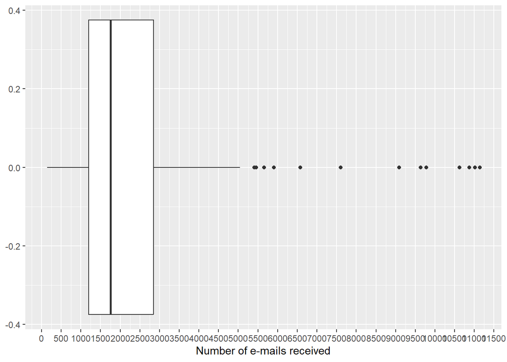

```r
# Create a Boxplot

breaks <- seq(0, 11500, by = 500)

ggplot(frequency_table_recipient, aes(x = EmailReceive)) +
  geom_boxplot() +
  scale_x_continuous(breaks = breaks) +
  xlab('Number of e-mails received')
```

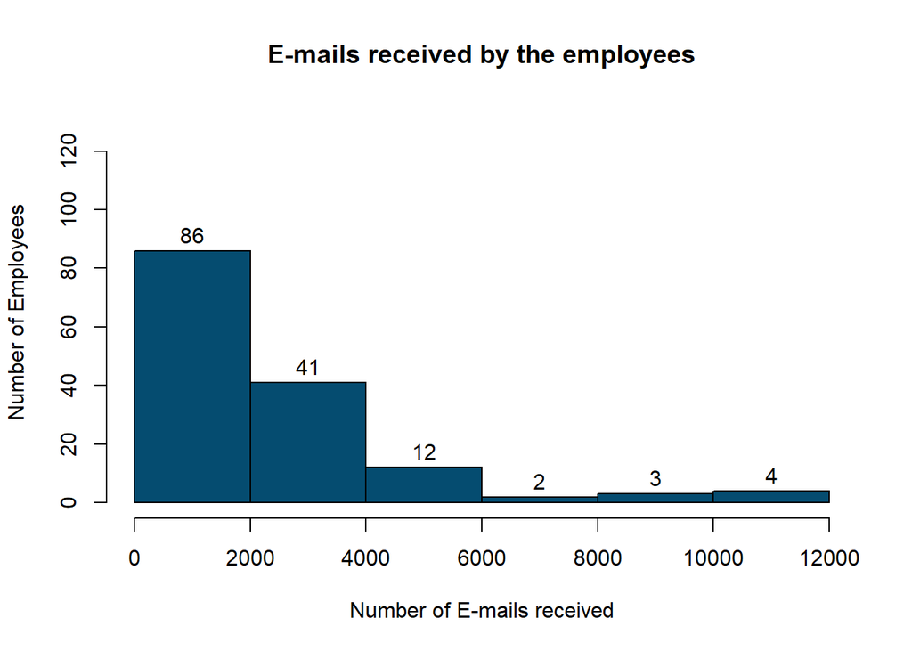

```r
# Visualize the data using an histogram

h <- hist(frequency_table_recipient$EmailReceive,
          breaks = 6,
          ylim = c(0, 130),
          col = '#054C70',
          border= 'black',
          main = 'E-mails received by the employees',
          xlab='Number of E-mails received',
          ylab = 'Number of Employees')
text(h$mids,h$counts,labels=h$counts, adj=c(0.5, -0.5))
```

Concerning the distribution, we can see that:  
- We have an important range of values: 140 to 11,137. This means that we have one employee who has received 140 e-mail and another who has received over 11,137 e-mails.  
- The majority of the employees received between 1,202 and 2,848 e-mails.With a median of 1,758 e-mails.  
- We have around 13 employees who are not part of this majority because they sent an important number of e-mails: more than 5,000.  
- We have a Right Skewed distribution. This makes sens, because we don’t receive the same number of e-mails depending on your status.

**c - Recipient Enron’s Most Active Employees**

```r
top_variable = 10
rest = top_variable - 3

top_employees_recipient = frequency_table_recipient %>% top_n(top_variable)
```

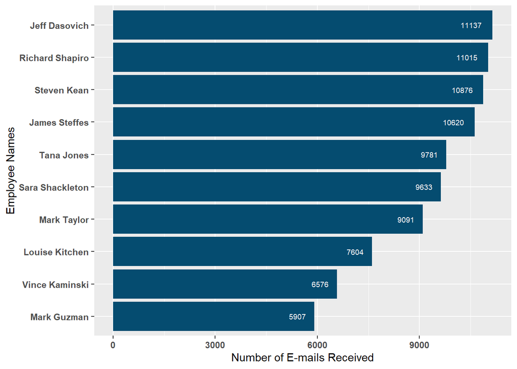

```r
ggplot(top_employees_recipient, aes(x=reorder(EmployeeName, EmailReceive), EmailReceive)) +
  geom_bar(stat = 'identity', fill = '#054C70') +
  coord_flip() +
  labs(x = 'Employee Names', y = 'Number of E-mails Received') +
  geom_text(
  aes(label = EmailReceive),
  size = 2.5,
  vjust = 0.5,
  hjust = 1.5,
  color = 'white') +
  theme(axis.text = element_text(face='bold'))
```

We now have an overview of the 10 employees who received the most e-mails and we can see that the top 4 are very close.

### 5.1.3 - Enron’s most active employees overall

**a - Comparison between sender and recipient**

Before we find out who is Enron’s most active employee overall, we can compare our 2 precedent DataFrame: Sender and Recipient.

```r
# Create two data frames: one for senders and one for recipients
frequency_table_sender_2 <- frequency_table_sender
frequency_table_recipient_2 <- frequency_table_recipient
frequency_table_sender_2$EmployeeName <- 'Employees Sender'
frequency_table_recipient_2$EmployeeName <- 'Employees Recipient'

frequency_table_sender_2 <- frequency_table_sender_2 %>%
  dplyr::rename('Emails' = 'EmailSent')
frequency_table_recipient_2 <- frequency_table_recipient_2 %>%
  dplyr::rename('Emails' = 'EmailReceive')

# Concatenate this 2 DataFrame
comparison_df <- bind_rows(frequency_table_sender_2, frequency_table_recipient_2)

head(comparison_df, 10)
```

|  | EmployeeName | Emails |
| --- | --- | --- |
| 1 | Employees Sender | 6273 |
| 2 | Employees Sender | 5838 |
| 3 | Employees Sender | 5100 |
| 4 | Employees Sender | 4797 |
| 5 | Employees Sender | 4437 |
| 6 | Employees Sender | 3686 |
| 7 | Employees Sender | 2784 |
| 8 | Employees Sender | 2549 |
| 9 | Employees Sender | 2277 |
| 10 | Employees Sender | 2275 |

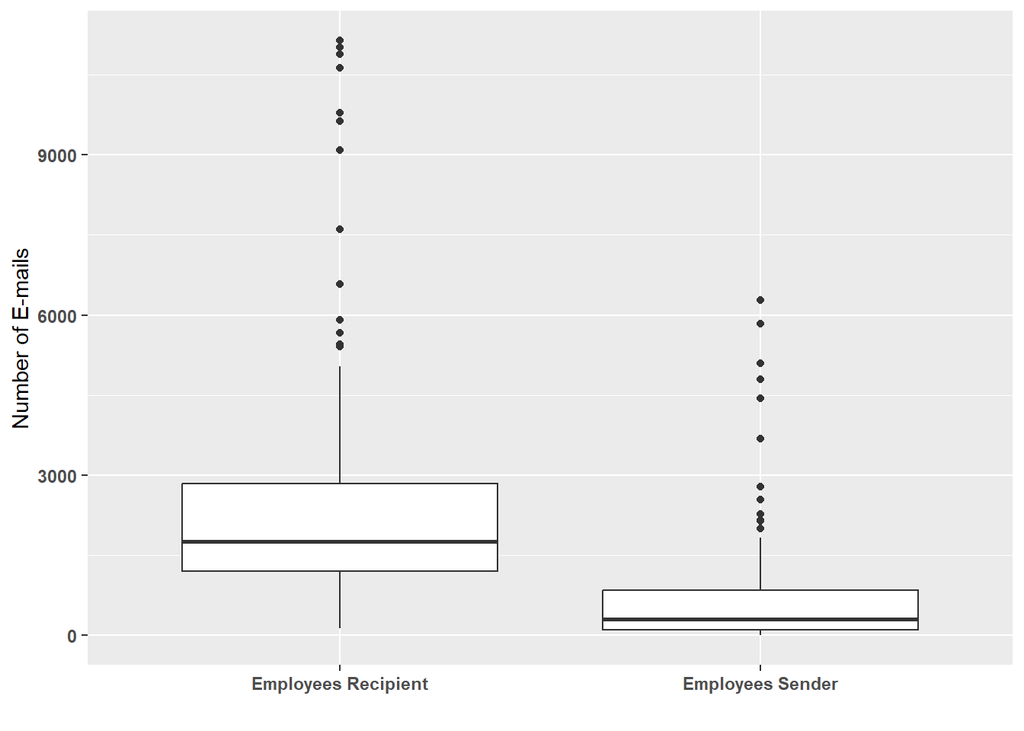

```r
# Create a Boxplot

ggplot(comparison_df, aes(x = EmployeeName, y = Emails)) +
  geom_boxplot() +
  ylab('Number of E-mails') +
  xlab('') +
  theme(axis.text = element_text(face='bold'))
```

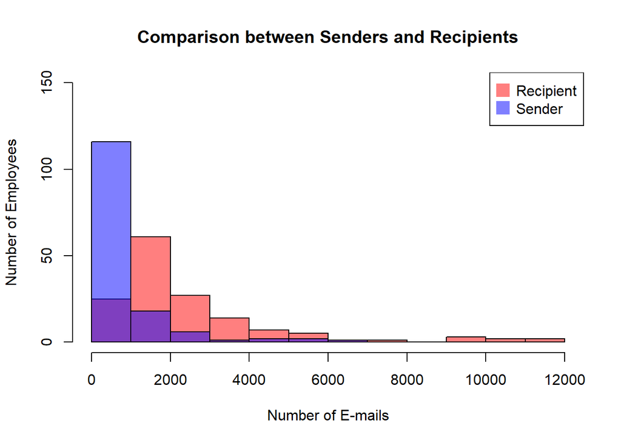

```r
hist(frequency_table_recipient_2$Emails,
          breaks = 8,
          ylim = c(0, 150),
          col = rgb(1,0,0,0.5),
          border= 'black',
          main = 'Comparison between Senders and Recipients',
          xlab='Number of E-mails',
          ylab = 'Number of Employees')

hist(frequency_table_sender_2$Emails,
     breaks = 6,
     ylim = c(0, 150),
     col=rgb(0,0,1,0.5),
     border= 'black',
     add=T)

legend("topright", legend=c('Recipient','Sender'), col=c(rgb(1,0,0,0.5),
     rgb(0,0,1,0.5)), pt.cex=2, pch=15 )
```

These two histograms show the same conclusion as the previous box plot. More precisely, we can see that for the sending employees, the Right Skewed distribution is more important than for the receiving employees.

**b - Enron’s most active employees overall**

To identify the most Enron Employee, we can concatenate our 2 precedent frequency_table:  
- frequency_table_sender  
- frequency_table_recipient

```r
frequency_table_sender <- frequency_table_sender %>%
                            dplyr::rename('Emails' = 'EmailSent')
frequency_table_recipient <- frequency_table_recipient %>%
                            dplyr::rename('Emails' = 'EmailReceive')

# Concatenate this 2 DataFrame
most_active_employee_df <- bind_rows(frequency_table_sender, frequency_table_recipient)

# Merge every row with the same employee to have a total
most_active_employee_df <- most_active_employee_df %>%
  group_by(EmployeeName) %>%
  dplyr::summarise(Emails=sum(Emails))

most_active_employee_df <- most_active_employee_df %>% as.data.frame()
most_active_employee_df <- most_active_employee_df[order(most_active_employee_df$Emails, decreasing = TRUE),]

paste('We have', nrow(most_active_employee_df), 'rows, corresponding to the number of unique employees')
```

```
## [1] "We have 149 rows, corresponding to the number of unique employees"
```

We now have a DataFrame containing all employees and the sum of e-mails sent and received. It would be interesting to look at a boxplot and histogram to analyze the distribution.

```r
summary <- summary(most_active_employee_df$Emails)
summary
```

```
##    Min. 1st Qu.  Median    Mean 3rd Qu.    Max.
##     196    1362    2147    3134    3837   17410
```

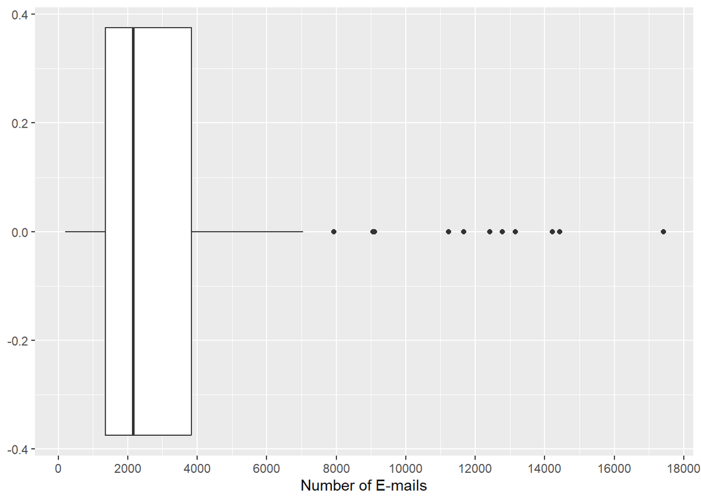

```r
# Plot the result
breaks <- seq(0, 18000, by = 2000)

ggplot(most_active_employee_df, aes(x = Emails)) +
  geom_boxplot() +
  scale_x_continuous(breaks = breaks) +
  xlab('Number of E-mails')
```

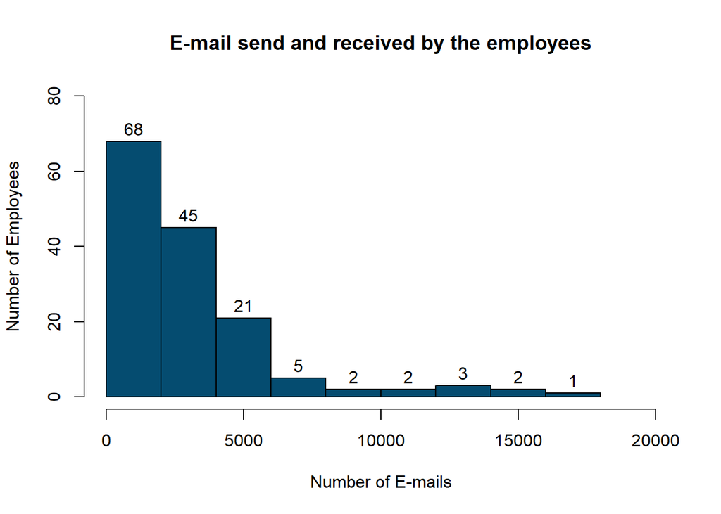

```r
# Create a histogram
breaks <- seq(0, 18000, by = 2000)

h <- hist(most_active_employee_df$Emails,
          breaks = 7,
          xlim = c(0, 20000),
          ylim = c(0, 80),
          col = '#054C70',
          border= 'black',
          main = 'E-mail send and received by the employees',
          xlab='Number of E-mails',
          ylab = 'Number of Employees')
text(h$mids,h$counts,labels=h$counts, adj=c(0.5, -0.5))
```

To finish we can now identify the most active employees:

```r
top_variable_2 = 10
rest_2 = top_variable - 3

top_employees_overall = most_active_employee_df %>% top_n(top_variable_2)
```

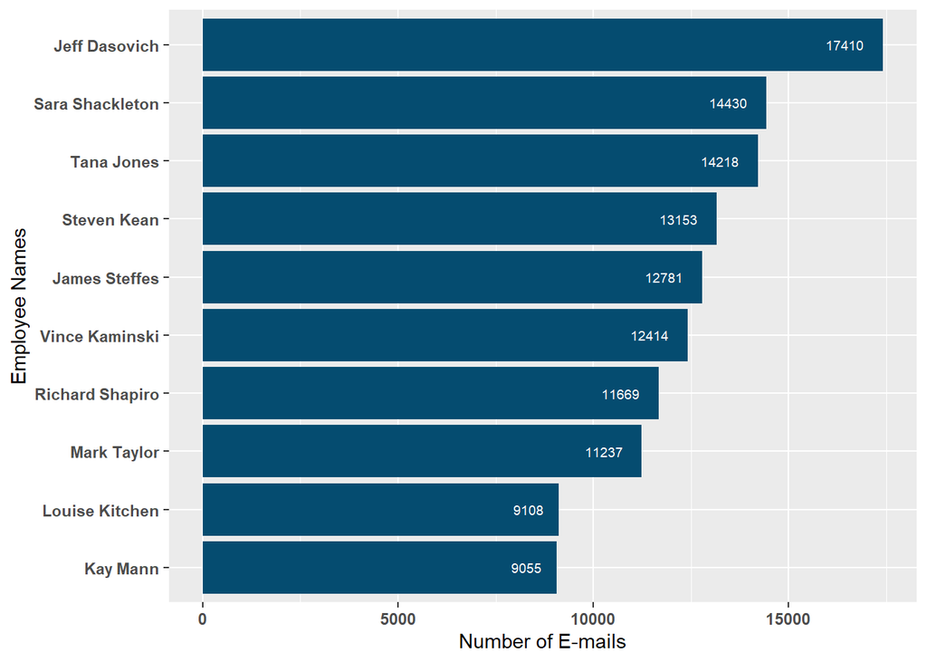

```r
ggplot(top_employees_overall, aes(x=reorder(EmployeeName, Emails), Emails)) +
  geom_bar(stat = 'identity', fill = '#054C70') +
  coord_flip() +
  labs(x = 'Employee Names', y = 'Number of E-mails') +
  geom_text(
  aes(label = Emails),
  size = 2.5,
  vjust = 0.5,
  hjust = 1.5,
  color = 'white') +
  theme(axis.text = element_text(face='bold'))
```

We can see a tendency. In this top 10 we have 3 groups:  
1. 1. The most active employee, Jeff Dasovich, who has a significant difference with the second employee.  
2. From the second to the eighth employee.  
3. After the 9th employee.

## 5.2 - In which status are we most likely to be active, in terms of sending and receiving e-mail?

Now that we have Enron’s most active employees, it will be interesting to analyze the relationship between status and e-mail activity. More precisely, we try to answer the question: In which status are we most likely to be active, in terms of sending and receiving e-mail?

First of all, we define activity as:  
- Sender - E-mails Sent  
- Recipient - E-mails Received  
- Overall - E-mails sent + E-mails received

As far as the analysis plan is concerned, we can begin by visualizing overall activity by status.

### 5.2.1 - Visualize the activity for each status

To start, we can display a bar plot to show the e-mail activity (e-mail sent and received) for each status.

We can use our “Most active employees” DataFrame, which groups all employees according to the number of e-mails sent and received. We can attached the status of each employee.

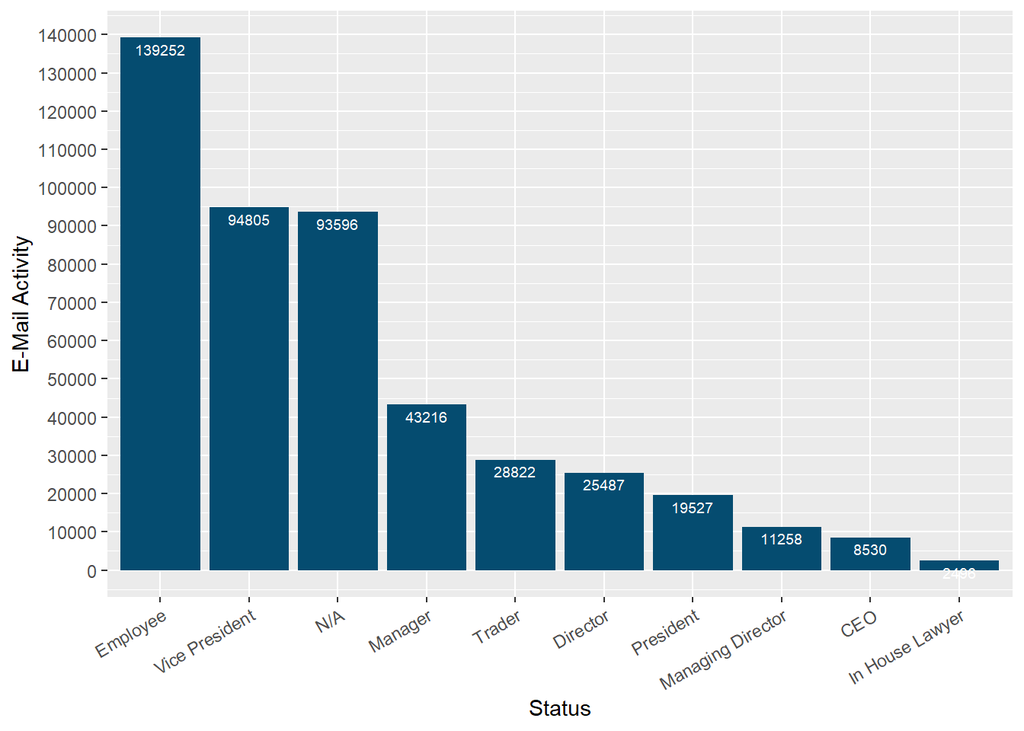

```r
# Join the Most Active Employee DataFrame with the Employee Table
status_activity_df <- most_active_employee_df %>% left_join(employee_df_2,
        by='EmployeeName')

# Keep the 2 most important columns. We don't need the Employee Name anymore
columns <- c('Emails', 'Status')
status_activity_df <- status_activity_df[columns]
status_activity_df <- status_activity_df[order(status_activity_df$Emails, decreasing = TRUE), ]

# Group every status to have the total of the activity
status_activity_df <- status_activity_df %>%
  group_by(Status) %>%
  dplyr::summarise(Emails=sum(Emails))

# Visualize the results using a bar plot
breaks <- seq(0,140000,10000)

status_activity_plot <- ggplot(status_activity_df, aes(x=reorder(Status, -Emails), Emails)) +
  geom_bar(stat = 'identity', fill = '#054C70') +
  labs(x = 'Status', y = 'E-Mail Activity') +
  geom_text(
    aes(label = Emails),
    size = 2.5,
    vjust = 1.5,
    hjust = 0.5,
    color = 'white') +
    theme(axis.text.x = element_text(angle = 30,
                                   vjust = 1,
                                   hjust=1)) +
  scale_y_continuous(breaks=breaks)

status_activity_plot
```

Without this information, we don’t have a reasonnable answer to our question because, maybe, in the employee status we have 50 people but just 2 have an important activity. Or maybe the CEO is alone. Depending on this results the answer to our question will be different.

So we need to do some research before choosing the bar chart data as the answer to our question.

It’s why, to answer our question, we have to:  
1. Check the size of each status.  
2. Compare the size of the status and its activity.  
3. Check the distribution of each status.

Then we can say whether or not we can keep this data to answer our question.

### 5.2.2 - Size of each status

We can check the number of people in each status to know if it will become problematic:

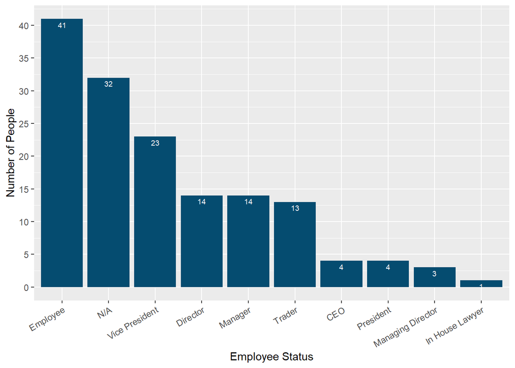

```r
# Create a small DataFrame with each status and the number of people tagged with that status
number_status_df <- employee_df_2[,'Status']
number_status_df <- frequency_table(number_status_df, 'TRUE')
number_status_df <- number_status_df %>%
                            dplyr::rename('Status' = 'column',
                                   'People' = 'Freq')

# Create a simple bar plot to visualize the results
breaks <- seq(0,50, 5)

number_status_plot <- ggplot(number_status_df, aes(x=reorder(Status, -People), People)) +
  geom_bar(stat = 'identity', fill = '#054C70') +
  labs(x = 'Employee Status', y = 'Number of People') +
  geom_text(
    aes(label = People),
    size = 2.5,
    vjust = 1.5,
    hjust = 0.5,
    color = 'white') +
    theme(axis.text.x = element_text(angle = 30,
                                   vjust = 1,
                                   hjust=1)) +
  scale_y_continuous(breaks=breaks)

number_status_plot
```

Now we can compare the size of the status and its activity

### 5.2.3 - Compare the size of the status and its activity

We can create a DataFrame that group the status with the number of people and the activity.

```r
# Join the 2 DataFrames

status_people_activity_df <- number_status_df %>% left_join(status_activity_df,
        by='Status')

status_people_activity_df
```

| Status | People | Emails |
| --- | --- | --- |
| Employee | 41 | 139252 |
| N/A | 32 | 93596 |
| Vice President | 23 | 94805 |
| Director | 14 | 25487 |
| Manager | 14 | 43216 |
| Trader | 13 | 28822 |
| CEO | 4 | 8530 |
| President | 4 | 19527 |
| Managing Director | 3 | 11258 |
| In House Lawyer | 1 | 2496 |

We can plot 2 bar chart to visualize the data:

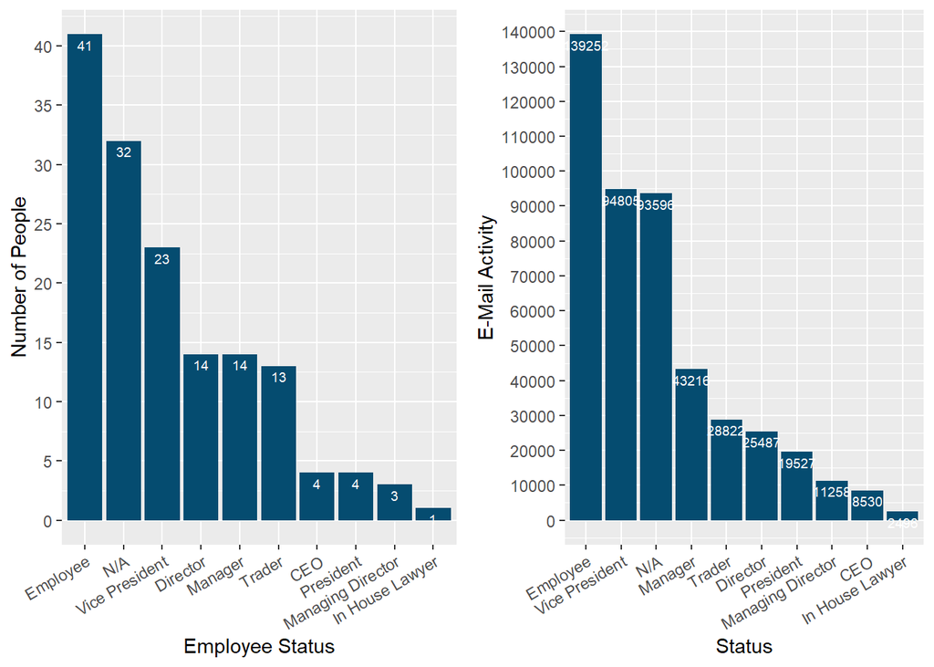

```r
grid.arrange(number_status_plot, status_activity_plot, ncol=2)
```

In the majority, more you have people in the status, more the activity is important.

Now that we know the size of each status, we can visualize their distribution.

### 5.2.4 - Check the distribution of each status

To do it, we can create a boxplot for each status and each type of activity:  
- Sender - E-mails Sent  
- Recipient - E-mails Received  
- Overall - E-mails sent + E-mails received

**a - Sender Group**

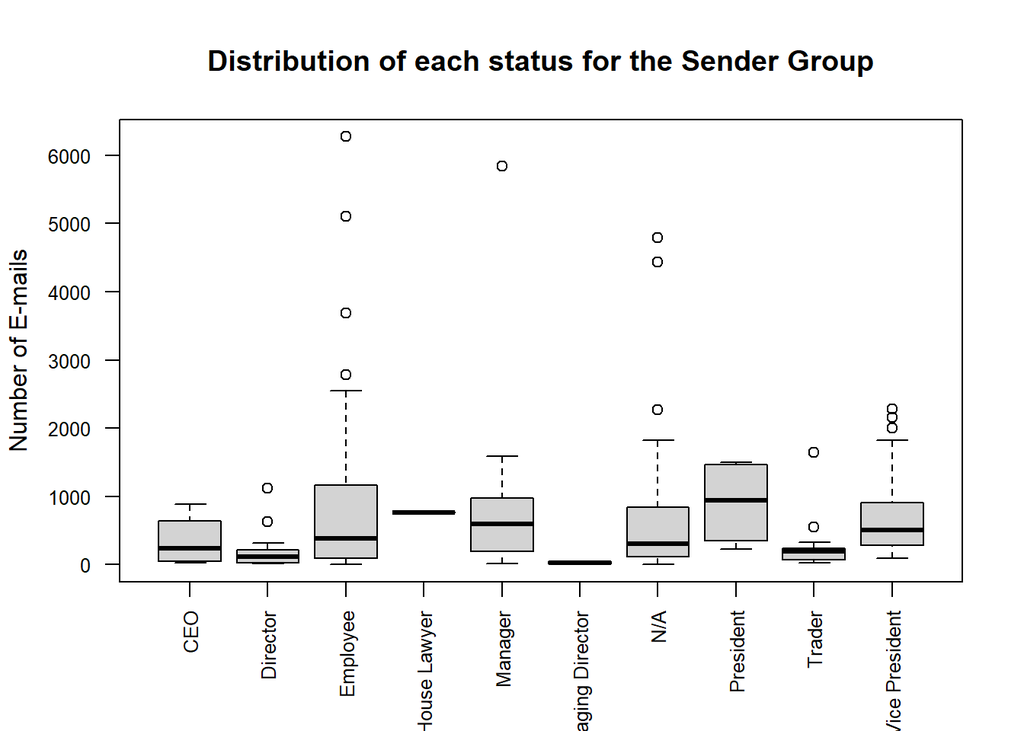

```r
# Create a specific DataFrame with the Employee Name, his status and his number of e-mails
columns_list <- c('EmployeeName', 'Emails', 'Status')
analysis_sender_df <- frequency_table_sender %>% left_join(employee_df_2,
        by='EmployeeName')
analysis_sender_df <- analysis_sender_df[,columns_list]

# Create the Box Plot
boxplot(analysis_sender_df$Emails ~ analysis_sender_df$Status,
        main = 'Distribution of each status for the Sender Group',
        xlab = "", ylab = "Number of E-mails",
        las=2,
        cex.axis=0.8)
```

For the Sender Group we can notice that:  
- We have significant outliers in the Employee, N/A status.  
- We have one important outlier in the Manager Status.  
- The distribution appears to be right skewed (Positive) for the CEO, Employee and N/A. This means that the majority of people sent fewer than 500 e-mails.

**b - Recipient Group**

**-> DataFrame**

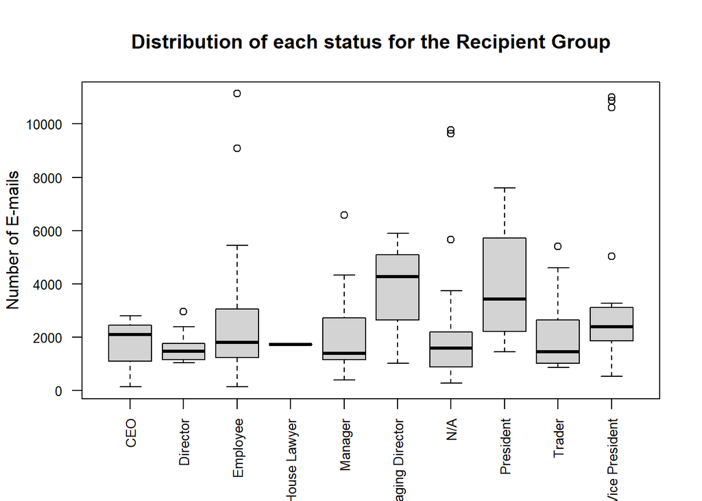

```r
# Create a specific DataFrame with the Employee Name, his status and his number of e-mails
analysis_recipient_df <- frequency_table_recipient %>% left_join(employee_df_2,
        by='EmployeeName')
analysis_recipient_df <- analysis_recipient_df[,columns_list]

# Create the Box Plot
boxplot(analysis_recipient_df$Emails ~ analysis_recipient_df$Status,
        main = 'Distribution of each status for the Recipient Group',
        xlab = "", ylab = "Number of E-mails",
        las=2,
        cex.axis=0.8)
```

**c - Overall Group**

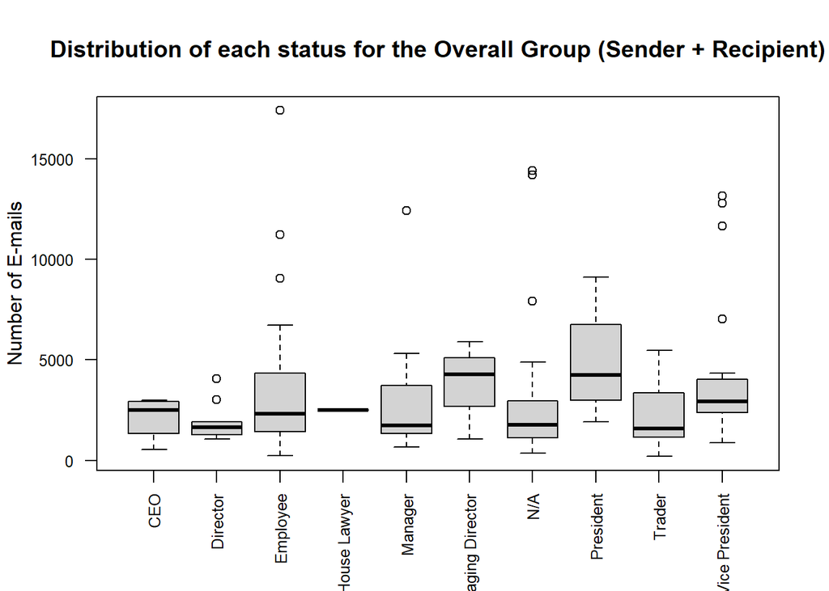

```r
# Create a specific DataFrame with the Employee Name, his status and his number of e-mails
analysis_overall_df <- most_active_employee_df %>% left_join(employee_df_2,
        by='EmployeeName')
analysis_overall_df <- analysis_overall_df[,columns_list]

# Create the Box Plot
boxplot(analysis_overall_df$Emails ~ analysis_overall_df$Status,
        main = 'Distribution of each status for the Overall Group (Sender + Recipient)',
        xlab = "", ylab = "Number of E-mails",
        las=2,
        cex.axis=0.8)
```

In conclusion, we can see that our three main statuses have the highest overall activity: Employee, N/A and Vice President also have the highest number of outliers.

### 5.2.5 - In which status are we most likely to be active, in terms of sending and receiving e-mail?

We have now:  
- The size of each status.  
- The knowledge of the presence of outliers.

So we can’t just keep the data from our first bar chart, we need to compare the activity of each status using the median and mean, which will help us represent the likely activity of an employee in a status.

To do that we will create a table for our 3 groups:  
- Sender  
- Recipient  
- Overall

**a - For the Sender Category**

```r
# Create an Empty DataFrame
status_list <- as.list(unique(employee_df_2['Status']))
status_sender_df <- data.frame()

# Iterate over ou list of status calling ou function to create our Dataframe
for (status in status_list[[1]]) {
  # We call our Status Analysis function to have a DataFrame with the mean and the median
  status_analysis_sender_df <- status_analysis(analysis_sender_df, status)
  # We concatenate this 2 DataFrame
  status_sender_df <- bind_rows(status_sender_df, status_analysis_sender_df)
}

# Add a column with the total of e-mail sent
analysis_sender_df_2 <- analysis_sender_df[,!names(analysis_sender_df) == 'EmployeeName']
analysis_sender_df_2 <- analysis_sender_df_2 %>%
  group_by(Status) %>%
  dplyr::summarise(Emails=sum(Emails))
status_sender_df <- analysis_sender_df_2 %>% left_join(status_sender_df,
        by='Status')
status_sender_df <- status_sender_df %>%
  dplyr::rename('TotalEmails' = 'Emails')

# Add the column of the number of people in the status
status_sender_df <- status_people_activity_df %>% left_join(status_sender_df,
        by='Status')
status_sender_df <- status_sender_df[,!names(status_sender_df) == 'Emails']

status_sender_df <- status_sender_df %>%
  relocate(Median) %>%
  relocate(Status)
status_sender_df <- status_sender_df[order(status_sender_df$Median, decreasing = TRUE),]

status_sender_df
```

|  | Status | Median | People | TotalEmails | Mean |
| --- | --- | --- | --- | --- | --- |
| 8 | President | 946 | 4 | 3619 | 905 |
| 10 | In House Lawyer | 763 | 1 | 763 | 763 |
| 5 | Manager | 594 | 14 | 12928 | 995 |
| 3 | Vice President | 502 | 23 | 17157 | 746 |
| 1 | Employee | 380 | 41 | 37064 | 927 |
| 2 | N/A | 308 | 32 | 24313 | 760 |
| 7 | CEO | 236 | 4 | 1388 | 347 |
| 6 | Trader | 193 | 13 | 3800 | 293 |
| 4 | Director | 112 | 14 | 3005 | 215 |
| 9 | Managing Director | 28 | 3 | 56 | 28 |

**b - For the Recipient Category**

```r
# Create an Empty DataFrame
status_list <- as.list(unique(employee_df_2['Status']))
status_recipient_df <- data.frame()

# Iterate over ou list of status calling ou function to create our Dataframe
for (status in status_list[[1]]) {
  # We call our Status Analysis function to have a DataFrame with the mean and the median
  status_analysis_recipient_df <- status_analysis(analysis_recipient_df, status)
  # We concatenate this 2 DataFrame
  status_recipient_df <- bind_rows(status_recipient_df, status_analysis_recipient_df)
}

# Add a column with the total of e-mail sent
analysis_recipient_df_2 <- analysis_recipient_df[,!names(analysis_recipient_df) == 'EmployeeName']
analysis_recipient_df_2 <- analysis_recipient_df_2 %>%
  group_by(Status) %>%
  dplyr::summarise(Emails=sum(Emails))
status_recipient_df <- analysis_recipient_df_2 %>% left_join(status_recipient_df,
        by='Status')
status_recipient_df <- status_recipient_df %>%
  dplyr::rename('TotalEmails' = 'Emails')

# Add the column of the number of people in the status
status_recipient_df <- status_people_activity_df %>% left_join(status_recipient_df,
        by='Status')
status_recipient_df <- status_recipient_df[,!names(status_recipient_df) == 'Emails']

status_recipient_df <- status_recipient_df %>%
  relocate(Median) %>%
  relocate(Status)
status_recipient_df <- status_recipient_df[order(status_recipient_df$Median, decreasing = TRUE),]

status_recipient_df
```

|  | Status | Median | People | TotalEmails | Mean |
| --- | --- | --- | --- | --- | --- |
| 9 | Managing Director | 4277 | 3 | 11202 | 3734 |
| 8 | President | 3426 | 4 | 15908 | 3977 |
| 3 | Vice President | 2404 | 23 | 77648 | 3376 |
| 7 | CEO | 2092 | 4 | 7142 | 1786 |
| 1 | Employee | 1801 | 41 | 102188 | 2493 |
| 10 | In House Lawyer | 1733 | 1 | 1733 | 1733 |
| 2 | N/A | 1589 | 32 | 69283 | 2166 |
| 4 | Director | 1477 | 14 | 22482 | 1606 |
| 6 | Trader | 1461 | 13 | 25022 | 2086 |
| 5 | Manager | 1396 | 14 | 30288 | 2164 |

**c - For the Overall Category**

```r
# Create an Empty DataFrame
status_list <- as.list(unique(employee_df_2['Status']))
status_overall_df <- data.frame()

# Iterate over ou list of status calling ou function to create our Dataframe
for (status in status_list[[1]]) {
  # We call our Status Analysis function to have a DataFrame with the mean and the median
  status_analysis_overall_df <- status_analysis(analysis_overall_df, status)
  # We concatenate this 2 DataFrame
  status_overall_df <- bind_rows(status_overall_df, status_analysis_overall_df)
}

# Add a column with the total of e-mail sent
analysis_overall_df_2 <- analysis_overall_df[,!names(analysis_overall_df) == 'EmployeeName']
analysis_overall_df_2 <- analysis_overall_df_2 %>%
  group_by(Status) %>%
  dplyr::summarise(Emails=sum(Emails))
status_overall_df <- analysis_overall_df_2 %>% left_join(status_overall_df,
        by='Status')
status_overall_df <- status_overall_df %>%
  dplyr::rename('TotalEmails' = 'Emails')

# And add the column of the number of people in the status
status_overall_df <- status_people_activity_df %>% left_join(status_overall_df,
        by='Status')
status_overall_df <- status_overall_df[,!names(status_overall_df) == 'Emails']

status_overall_df <- status_overall_df %>%
  relocate(Median) %>%
  relocate(Status)
status_overall_df <- status_overall_df[order(status_overall_df$Median, decreasing = TRUE),]

status_overall_df
```

|  | Status | Median | People | TotalEmails | Mean |
| --- | --- | --- | --- | --- | --- |
| 9 | Managing Director | 4277 | 3 | 11258 | 3753 |
| 8 | President | 4247 | 4 | 19527 | 4882 |
| 3 | Vice President | 2919 | 23 | 94805 | 4122 |
| 10 | In House Lawyer | 2496 | 1 | 2496 | 2496 |
| 7 | CEO | 2494 | 4 | 8530 | 2133 |
| 1 | Employee | 2323 | 41 | 139252 | 3397 |
| 2 | N/A | 1774 | 32 | 93596 | 2925 |
| 5 | Manager | 1738 | 14 | 43216 | 3087 |
| 4 | Director | 1642 | 14 | 25487 | 1821 |
| 6 | Trader | 1573 | 13 | 28822 | 2218 |

**d - Conclusion**

Initially, our aim was to analyze the relationship between e-mail activity and status. And more precisely, in which status are we most likely to be active?

Consequently, we conclude that the number of e-mails sent and received does not really represent the actual activity of the person in a status, but that it does represent the overall activity of the status. That’s why, to answer our question, we used the median and the mean. These methods enabled us to understand one important thing:

**Just because a status’s overall activity is high, doesn’t mean you’re more likely to have high activity yourself.**

Managing Director, President and In House Lawyer status have fewer than 5 people, but the median is higher than that for Employee and N/A. positions.

We can conclude from this that you’re more likely to be active, in terms of sending and receiving e-mails, if you’re a Managing Director, President, and In House Layer.

## 5.3 - When was e-mail activity highest? And why?

For each message, in our Enron DataFrame we have:  
- The full date  
- The day  
- The month  
- The year

To answer our question, we can divide the analysis into several stages:  
- Compare the global activity  
- Compare the monthly activity between years (for the busiest years)

### 5.3.1 - Compare the global activity

```r
cat('The minimum year is', min(enron_df$DateYear), 'The maximum year is', max(enron_df$DateYear),'.')
```

```
## The minimum year is 1997 The maximum year is 2020 .
```

To start we can create a frequency table for the years:

```r
fq_years_df <- frequency_table(enron_df$DateYear, 'TRUE')
fq_years_df <- fq_years_df %>%
  dplyr::rename('Years' = 'column',
         'Frequency' = 'Freq')
fq_years_df
```

|  | Years | Frequency |
| --- | --- | --- |
| 5 | 2001 | 1350994 |
| 4 | 2000 | 512573 |
| 6 | 2002 | 177810 |
| 3 | 1999 | 22631 |
| 2 | 1998 | 350 |
| 7 | 2004 | 54 |
| 1 | 1997 | 3 |
| 9 | 2020 | 2 |
| 8 | 2007 | 1 |

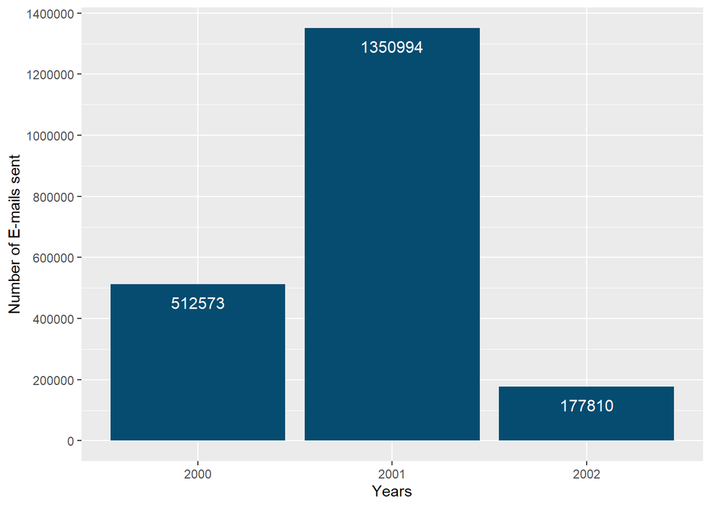

```r
# Keep our three first rows
fq_years_df_2 <- fq_years_df[fq_years_df$Years %in% c(2000,2001,2002), ]


# Create can plot our result
breaks <- seq(0,1400000, 200000)
ggplot(fq_years_df_2, aes(Years, Frequency)) +
  geom_bar(stat = 'identity', fill = '#054C70') +
  labs(x = 'Years', y = 'Number of E-mails sent') +
  geom_text(
    aes(label = Frequency),
    size = 4,
    vjust = 2,
    hjust = 0.5,
    color = 'white') +
  scale_y_continuous(breaks=breaks)
```

We can notice that we have a significant difference between our first three results and the others.

So we have a specific period where e-mail activity has increased. This increase could be explained by a specific chronology of events (https://www.famous-trials.com/enron/1789-chronology):  
- 2000: Enron is experiencing strong growth and the company is called “the most innovative large company in the United States.”  
1. 2001:  
- Some media outlets are wondering whether Enron is overpriced.  
- April: An analyst questions Enron’s failure to release a balance sheet along with its earnings statements.  
- August: The CEO resigns.  
- August: The Vice-President sends an anonymous letter to the new CEO criticizing the company’s accounting practices.  
- October: The SEC begins an informal probe of Enron.  
- End of the year: The stock price falls and the company is close to bankruptcy.  
2. 2002:  
- August: Enron accounting firm Arthur Arthur Andersen surrenders its CPA license and its 85,000 employees lose their jobs.  
- October: Andy Fastow is indicted on 78 counts of fraudulent conduct.

And the story continues beyond our dates.

So, the year 2001 is where the most activity is recorded, and when we look to the chronology it’s logical. Indeed, 2000 was one of Enron’s best years, but 2001 was the year of revelations, scandals, accusations, resignations, collapse in share prices and the beginning of a bankruptcy.

### 5.3.2 - Compare monthly activity between years

On the basis of these 3 years, it will be interesting to analyze more precisely the evolution of business by month.

**a - Global activity over three years**

To begin with, we can analyze overall activity by month over the three years:

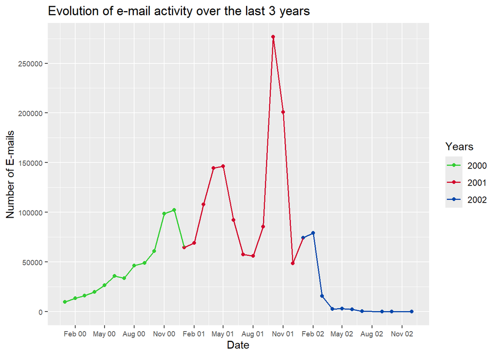

```r
# Create a New DataFrame
compare_m_y_df <- enron_df[enron_df$DateYear %in% c(2000,2001,2002),]

# Extract Year and Month
compare_m_y_df$MonthYear <- format(as.Date(compare_m_y_df$Date), '%Y-%m')

# Group by Year and Month
compare_m_y_df <- compare_m_y_df %>% group_by(MonthYear) %>%
  dplyr::summarise(EmailNumber=n(),.groups = 'drop') %>%
  as.data.frame()

# Add the day 1 to have a date format
compare_m_y_df$Date <- as.Date(paste(compare_m_y_df$MonthYear, "-01", sep=""))
compare_m_y_df <- compare_m_y_df[,!names(compare_m_y_df) == 'MonthYear']

# Add a column with a specific color for each year
compare_m_y_df <- compare_m_y_df %>%
  mutate(Color = case_when(between(Date, as.Date('2000-01-01'), as.Date('2000-12-01')) ~ '#32CD32',
                          between(Date, as.Date('2001-01-01'), as.Date('2001-12-01')) ~ '#D2042D',
         between(Date, as.Date('2002-01-01'), as.Date('2002-12-01')) ~ '#0047AB',
                              TRUE ~ '0'))

# Plot the Years
breaks_y <- seq(0,500000, 50000)
ggplot(compare_m_y_df, aes(x=Date, y=EmailNumber)) +
  geom_point(aes(colour=Color, group=1), size=1.5) +
  geom_line(aes(colour=Color, group=1), linewidth=0.6) +
  scale_color_identity(name = 'Years',
                       breaks = c('#32CD32', '#D2042D', '#0047AB'),
                       labels = c('2000', '2001', '2002'),
                       guide = 'legend') +
  scale_x_date(date_breaks = '3 month', date_labels = "%b %y") +
  scale_y_continuous(breaks=breaks_y) +
  ggtitle('Evolution of e-mail activity over the last 3 years') +
  labs(x = 'Date', y = 'Number of E-mails') +
  theme(axis.text=element_text(size=7))
```

**b - Precise activity over three years**

We can add a more precise monthly comparison:

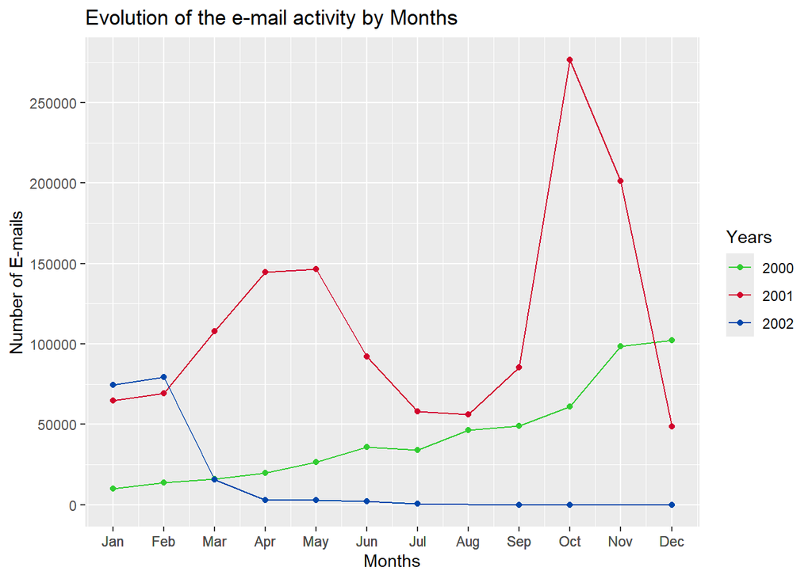

```r
# Create a New DataFrame
compare_m_y_df_2 <- enron_df[enron_df$DateYear %in% c(2000,2001,2002),]

# Extract Year and Month
compare_m_y_df_2$MonthYear <- format(as.Date(compare_m_y_df_2$Date), '%Y-%m')

# Group by Year and Month
compare_m_y_df_2 <- compare_m_y_df_2 %>% group_by(MonthYear) %>%
  dplyr::summarise(EmailNumber=n(),.groups = 'drop') %>%
  as.data.frame()

# Add the day 1 to have a date format
compare_m_y_df_2$Month <- as.Date(paste(compare_m_y_df_2$MonthYear, "-01", sep=""))
compare_m_y_df_2 <- compare_m_y_df_2[,!names(compare_m_y_df_2) == 'MonthYear']

# Extract the Year
compare_m_y_df_2$Years <- format(compare_m_y_df_2$Month, format="%Y")

# Extract the month in a numerical format
compare_m_y_df_2$MonthNumber <- as.numeric(format(as.Date(compare_m_y_df_2$Month),"%m"))

# Create an abreviation of the Months
compare_m_y_df_2$Month  <- months(as.Date(compare_m_y_df_2$Month), abbreviate=TRUE)

# Plot the Years
breaks_y <- seq(0,500000, 50000)
ggplot(data = compare_m_y_df_2, aes(x = MonthNumber, y = EmailNumber, group = Years, colour=Years)) +
  geom_line() +
  geom_point() +
  scale_x_continuous(breaks = compare_m_y_df_2$MonthNumber, labels = compare_m_y_df_2$Month) +
  scale_y_continuous(breaks=breaks_y) +
  ggtitle('Evolution of the e-mail activity by Months') +
  labs(x = 'Months', y = 'Number of E-mails') +
  scale_color_manual(values=c('#32CD32', '#D2042D', '#0047AB'))
```

## 5.4 - Analysis of the content of the messages

Analyzing the content of the messages, we would like to answer the question: What were the Enron employees talking about?

To do this, we need to work with the “subject” column in the Message DataFrame.

We will go through various stages:  
1. Text Processing  
2. Most frequently used words  
3. Number of words per year  
4. Subjects Analysis

We will use:  
- “tm” library which allows us to access a range of functions for processing text data.  
- “workcloud” library to create workcloud (most frequently used words).

### 5.4.1 - Text Processing

To start, we have to clean the text:

```r
# Export the subject column
words_analysis <- message_df_2$Subject

# Transform the text into a “corpus” class, enabling us to apply certain functions
words_analysis_corpus <- Corpus(VectorSource(words_analysis))

# Clean the data: remove punctuation, lowercase, remove Numbers, remove "Stopwords"
words_analysis_corpus <- words_analysis_corpus %>%
  tm_map(removeNumbers) %>%
  tm_map(removePunctuation) %>%
  tm_map(stripWhitespace)
words_analysis_corpus <- tm_map(words_analysis_corpus, content_transformer(tolower))
words_analysis_corpus <- tm_map(words_analysis_corpus, removeWords, stopwords("english"))

# After some visualizations, We can remove a list of some specific words
list_of_words <- c('new', 'date', 'hourahead', 'update', 'daily', 'weekly', 'today', 'start', 'revised', 'fwd', 'fw', 'master', 'inc', 'lay', 'list', 'call', 'news', 'access','change', 'informationsda', 'please', 'company', 'demand', 'codesite', 'management', 'hour', 'may', 'schedule', 'capacity', 'summary', 'week', 'notification', 'group', 'office', 'information', 'plan', 'final', 'corp', 'weekend', 'email', 'price', 'data', 'services', 'review', 'infos','status', 'day', 'info', 'confirmation', 'notice', 'free', 'response', 'proceeds', 'time', 'online', 'reminder', 'memo', 'document', 'donate', 'contact', 'message', 'action', 'project', 'updated', 'options', 'staff', 'release', 'global', 'comments', 'program', 'mentions', 'changes', 'natural', 'tw', 'mtg', 'business','pg', 'ofo', 'watch', 'center','lsda')

words_analysis_corpus <- tm_map(words_analysis_corpus, function(x)removeWords(x,list_of_words))
```

### 5.4.2 - Most frequently used words

**a - Wordcloud**

Now, with cleaner text, we can visualize the most frequently used words:

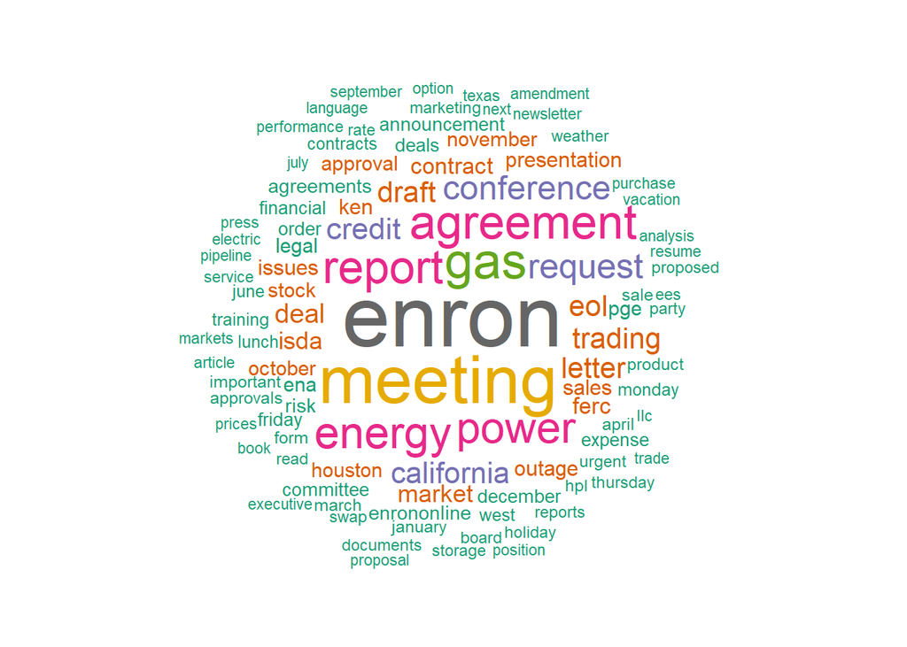

```r
set.seed(123456)
wordcloud(words_analysis_corpus, max.words = 100, colors = brewer.pal(8, 'Dark2'), random.order=FALSE, rot.per=0)
```

This visualization helps us better understand the most frequently used word but we don’t know the exact proportion of the word’s use.

**b - Word count DataFrame**

```r
# Create a tibble that is near to a data frame
words_count_df <- tibble(Text = words_analysis)

# Create a tibble with one row by word
words_count_df <- words_count_df %>%
                  unnest_tokens(output = word, input = Text)

# Remove stop words
words_count_df <- words_count_df %>%
                   anti_join(stop_words)

# Create a tibble with each word associated with the number of times it has been used
words_count_df_2 <- words_count_df %>% dplyr::count(word, sort = TRUE)

# Rename columns
words_count_df_2 <- words_count_df_2 %>%
  dplyr::rename('Words' = 'word',
         'Frequency' = 'n')

# Continue to clean the data by deleting the numerica values
words_count_df_2$Words <- gsub('[[:digit:]]+', '', words_count_df_2$Words)
words_count_df_2$Words <- str_replace_all(words_count_df_2[['Words']], "[[:punct:]]", "")
words_count_df_2 <- words_count_df_2[words_count_df_2$Words != '',]
words_count_df_2 <- words_count_df_2[!(words_count_df_2$Words %in% list_of_words),]

words_count_df_2
```

| Words | Frequency |
| --- | --- |
| enron | 12008 |
| meeting | 8267 |
| gas | 5987 |
| agreement | 5428 |
| report | 5211 |
| energy | 5142 |
| power | 4967 |
| request | 3598 |
| conference | 3373 |
| credit | 2960 |

[output cut: 9990 more lines]

To finish, we can plot the result:

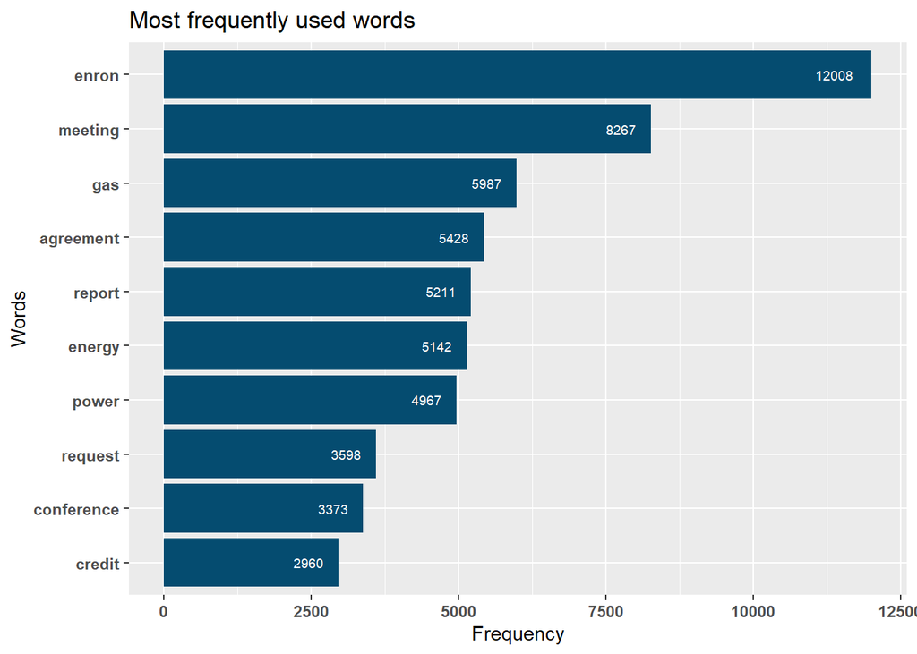

```r
top_number <- 10
words_analysis_plot <- words_count_df_2 %>% top_n(top_number)
ggplot(words_analysis_plot, aes(x=reorder(Words, Frequency), Frequency)) +
  geom_bar(stat = 'identity', fill = '#054C70') +
  coord_flip() +
  labs(x = 'Words', y = 'Frequency') +
  geom_text(
  aes(label = Frequency),
  size = 2.5,
  vjust = 0.5,
  hjust = 1.5,
  color = 'white') +
  theme(axis.text = element_text(face='bold')) +
  ggtitle('Most frequently used words')
```

### 5.4.3 - Number of words per year

It will be interesting to visualize the most used words depending of the period of time.

**a - Create a DataFrame**

The first is to create a specific DataFrame with the count for each words depending of the year:

```r
# We create 3 Dataframe for each year
words_count_00 <- message_df_2[message_df_2$DateYear == 2000, ]
words_count_01 <- message_df_2[message_df_2$DateYear == 2001, ]
words_count_02 <- message_df_2[message_df_2$DateYear == 2002, ]

# We follow the same process for each Year
# Year 2000
words_count_00 <- words_count_00$Subject
words_count_00_df <- tibble(Text = words_count_00)
words_count_00_df <- words_count_00_df %>%
                  unnest_tokens(output = word, input = Text)
words_count_00_df <- words_count_00_df %>%
                   anti_join(stop_words)
words_count_00_df <- words_count_00_df %>% dplyr::count(word, sort = TRUE)
words_count_00_df <- words_count_00_df %>%
  dplyr::rename('Words' = 'word',
         'Year2000' = 'n')
words_count_00_df$Words <- gsub('[[:digit:]]+', '', words_count_00_df$Words)
words_count_00_df <- words_count_00_df[words_count_00_df$Words != '',]
words_count_00_df <- words_count_00_df[!(words_count_00_df$Words %in% list_of_words),]
words_count_00_df <- as.data.frame(apply(words_count_00_df,2, function(x) gsub("\\s+", "", x)))

# Year 2001
words_count_01 <- words_count_01$Subject
words_count_01_df <- tibble(Text = words_count_01)
words_count_01_df <- words_count_01_df %>%
                  unnest_tokens(output = word, input = Text)
words_count_01_df <- words_count_01_df %>%
                   anti_join(stop_words)
words_count_01_df <- words_count_01_df %>% dplyr::count(word, sort = TRUE)
words_count_01_df <- words_count_01_df %>%
  dplyr::rename('Words' = 'word',
         'Year2001' = 'n')
words_count_01_df$Words <- gsub('[[:digit:]]+', '', words_count_01_df$Words)
words_count_01_df <- words_count_01_df[words_count_01_df$Words != '',]
words_count_01_df <- words_count_01_df[!(words_count_01_df$Words %in% list_of_words),]
words_count_01_df <- as.data.frame(apply(words_count_01_df,2, function(x) gsub("\\s+", "", x)))

# Year 2002
words_count_02 <- words_count_02$Subject
words_count_02_df <- tibble(Text = words_count_02)
words_count_02_df <- words_count_02_df %>%
                  unnest_tokens(output = word, input = Text)
words_count_02_df <- words_count_02_df %>%
                   anti_join(stop_words)
words_count_02_df <- words_count_02_df %>% dplyr::count(word, sort = TRUE)
words_count_02_df <- words_count_02_df %>%
  dplyr::rename('Words' = 'word',
         'Year2002' = 'n')
words_count_02_df$Words <- gsub('[[:digit:]]+', '', words_count_02_df$Words)
words_count_02_df <- words_count_02_df[words_count_02_df$Words != '',]
words_count_02_df <- words_count_02_df[!(words_count_02_df$Words %in% list_of_words),]
words_count_02_df <- as.data.frame(apply(words_count_02_df,2, function(x) gsub("\\s+", "", x)))

# Join the three DafaFrame
words_count_years_df <- words_count_01_df %>% left_join(words_count_00_df,
        by='Words')
words_count_years_df <- words_count_years_df %>% left_join(words_count_02_df,
        by='Words') %>%
  distinct(Words, Year2000, Year2001, Year2001, .keep_all =TRUE)

# Reorder the final DataFrame
words_count_years_df <- words_count_years_df[, c('Words', 'Year2000', 'Year2001', 'Year2002')]

# Remove the duplicates
words_count_years_df_2 = words_count_years_df[!duplicated(words_count_years_df$Words),]

# Convert each year column into numeric format
words_count_years_df_2$Year2001 <- as.numeric(as.character(words_count_years_df_2$Year2001))
words_count_years_df_2$Year2000 <- as.numeric(as.character(words_count_years_df_2$Year2000))
words_count_years_df_2$Year2002 <- as.numeric(as.character(words_count_years_df_2$Year2002))

# Order each column starting with 2001, as this is the most important year.
words_count_years_df_2 <- words_count_years_df_2[order(words_count_years_df_2$Year2001,
                                                                     words_count_years_df_2$Year2000,
                                                                     words_count_years_df_2$Year2002, decreasing=TRUE), ]


# Select the top 10 rows
words_count_years_df_2 <- words_count_years_df_2[1:10, ]

# Rename the columns
words_count_years_df_2 <- words_count_years_df_2 %>%
  dplyr::rename('2000' = 'Year2000',
         '2001' = 'Year2001',
         '2002' = 'Year2002')

# Transform the Dataframe into Melt Format
words_count_years_melt <- reshape2::melt(words_count_years_df_2, id = c('Words'))
words_count_years_melt$value <- as.numeric(words_count_years_melt$value)
words_count_years_melt <- words_count_years_melt %>%
  dplyr::rename('Years' = 'variable',
         'Count' = 'value')
```

**b - Create a Bar Chart**

Now, the first option is to create a bar chart with the most frequently used words over the years:

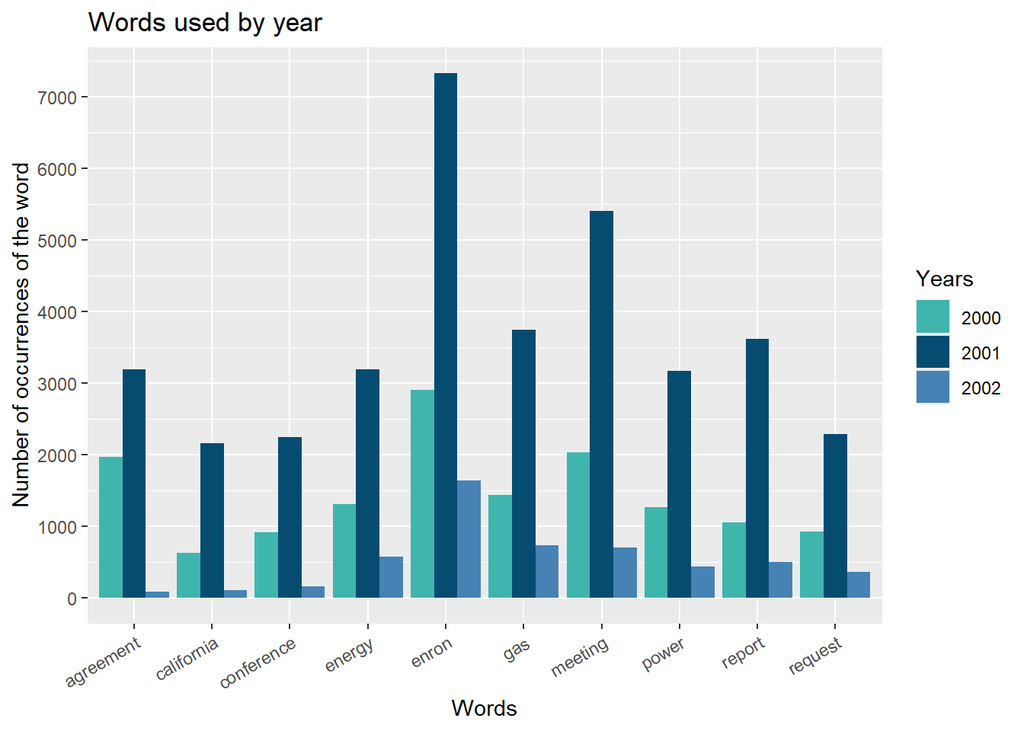

```r
breaks_words <- seq(0, 7500, 1000)

ggplot(words_count_years_melt, aes(Words, Count, fill = Years)) +
  geom_bar(stat='identity', position = "dodge") +
  labs(title='Words used by year') +
  ylab('Number of occurrences of the word') +
  xlab('Words') +
  theme(axis.text.x = element_text(angle = 30,
                                   vjust = 1,
                                   hjust=1)) +
  scale_y_continuous(breaks=breaks_words) +
  scale_fill_manual(values = c("#40B5AD","#054C70", '#4682B4'))
```

**c - Create a Heatmap**

The second option is to create a heat map with the most frequently used words over the years:

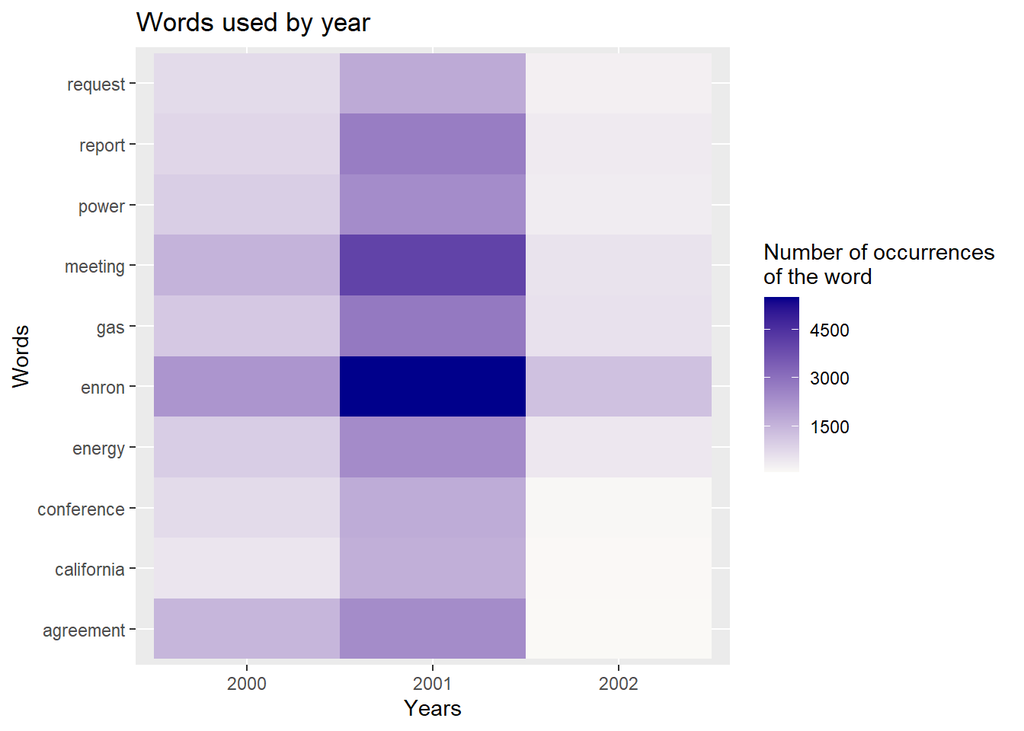

```r
ggplot(words_count_years_melt, aes(Years, Words, fill = Count)) +
  geom_tile() +
  scale_fill_gradient(low = '#FAF9F6', high = '#00008B',
                      labels = c('0', '1500', '3000', '4500', '7500')) +
  ylab('Words') +
  xlab('Years') +
  ggtitle('Words used by year') +
  scale_colour_brewer("Diamond\nclarity")+
  guides(fill = guide_colourbar(title = 'Number of occurrences \nof the word'))
```

### 5.4.4 - Subjects Analysis

The most frequently used words help us to understand or guess the subject of various e-mails and conversations:  
- We have the lexical field of the oil and gas industry: gas, energy, power, electric…  
- We can identify the different types of Enron activities: meeting, conference, presentation, training…  
- We have the lexical field of business and finance: market, credit, business, contract, stock, expense, marketing…  
- We can identify the type of messages: agreement, request, approval, urgent, problems, breakdown.  
- We can identify Enron’s various partners: Eol, Isda…

By combining these results with the number of occurrences of specific words, we can guess that:  
- The company was a business in the oil and gas industry.  
- In terms of organization, Enron had many meetings.  
- One of the most talked-about topics was business, sales and finance, as we have specific words often used: stock, market, credit, sales, deal, draft…  
- We have some information on the company with “ken” (Kenneth Lee Lay), who was the CEO, and Houston, where the head office was located.  
- We can see that Enron had to deal with problems and breakdowns.